# Monitoria de Econometria I (REC2301/2022)

# Monitorias

- **Monitoria 1 (18/08)**: Introdução ao R, Operações básicas e Objetos (simples e vetores)
  - [script](https://fhnishida.github.io/fearp/rec2301/monitoria_01.R) | [vídeo](https://www.youtube.com/watch?v=WclDYhHj_Fk)
- **Monitoria 2 (25/08)**: Objetos (vetores, matrizes, listas e data frames) e Subconjuntos de objetos (até remoção de valores ausentes)
  - [script](https://fhnishida.github.io/fearp/rec2301/monitoria_02.R) | [vídeo](https://www.youtube.com/watch?v=0DIlCKZb1gQ) | [lista prática 1](https://fhnishida.github.io/fearp/rec2301/Lista_Pratica_1.pdf) | [solução](https://fhnishida.github.io/fearp/rec2301/Lista_Pratica_1_solucao.pdf)
- **Monitoria 3 (01/09)**: Operações vetoriais/matriciais, Estruturas de controle (if/else, for e while), e Exemplos de otimização de funções
  - [script](https://fhnishida.github.io/fearp/rec2301/monitoria_03.R) | [vídeo](https://www.youtube.com/watch?v=N2pkt0CBUOc)
- **Monitoria 4 (22/09)**: Funções, Resumo e Manipulação de dados
  - [script](https://fhnishida.github.io/fearp/rec2301/monitoria_04.R) | [vídeo](https://www.youtube.com/watch?v=cZpXDH96XPw)
- **Monitoria 5 (29/09)**: Manipulação de dados via `dplyr`
  - [script](https://fhnishida.github.io/fearp/rec2301/monitoria_05.R) | [vídeo](https://www.youtube.com/watch?v=TycerslMhnU) | [lista prática 2](https://fhnishida.github.io/fearp/rec2301/Lista_Pratica_2.pdf) | [solução](https://fhnishida.github.io/fearp/rec2301/Lista_Pratica_2_solucao.pdf)
- **Monitoria 6 (06/10)**: Distribuições, Simulação, Intervalo de Confiança, Teste *t* e P-valor
  - [script](https://fhnishida.github.io/fearp/rec2301/monitoria_06.R) | [vídeo](https://www.youtube.com/watch?v=wkOGblJGuIw)
- **Monitoria 7 (13/10)**: Modelo de regressão simples, função `lm()`, transformação log e diferença de médias
  - [script](https://fhnishida.github.io/fearp/rec2301/monitoria_07.R) | [vídeo](https://www.youtube.com/watch?v=G0za24e0qj4) | [lista prática 3](https://fhnishida.github.io/fearp/rec2301/Lista_Pratica_3.pdf) | [solução](https://fhnishida.github.io/fearp/rec2301/Lista_Pratica_3_solucao.pdf)

# PROGRAMAÇÃO EM R =======

# Introdução ao R

- Baseado, principalmente, nos cursos da [*Especialização em Data Science*](https://www.coursera.org/specializations/jhu-data-science) da universidade John Hopkins (disponível no Coursera).
- Não é possível fazer a Especialização gratuitamente, mas é possível “participar como ouvinte” (*audit course*), o que permite acessar quase todo material (mas não pode fazer os testes e, portanto, não ganha certificado ao concluí-lo).
- Em cada tema abordado serão citadas as fontes, além de incluir aos vídeos dos cursos citados acima para que possam aprofundar nos estudos.

## Instalação do R e R Studio

- [Installing R (John Hopkins/Coursera)](https://www.coursera.org/learn/data-scientists-tools/lecture/y6mU2/installing-r)
1. Instalação da base do R ([CRAN](https://cran.r-project.org))
   - Download R for Windows > base > Download R X.X.X for Windows
   - Se o computador for 64-bits, opte pela versão 64-bits
2. Instalação do Rtools ([CRAN](https://cran.r-project.org))
   - Download R for Windows > Rtools > Installing Rtools > rtools40-x86_XX.exe
   - É um conjunto de ferramentas de compilação de várias linguagens (C, C++ e Fortran) que são necessários em alguns pacotes no R
3. Instalação do RStudio ([RStudio Dowload](https://www.rstudio.com/products/rstudio/download/#download))
   - Download RStudio Desktop
   - É uma interface de usuário para facilitar o uso do R

## Usando o R Studio

- [RStudio Tour (John Hopkins/Coursera)](https://www.coursera.org/learn/data-scientists-tools/lecture/0fUNC/rstudio-tour)

RStudio é dividido em 4 quadrantes:

- superior/esquerdo: source - onde ficam “blocos de nota” (scripts) com comandos a serem salvos
- superior/direito: ambiente - visualizar variáveis
- inferior/esquerdo: console - executar os comandos e ver resultados (é o R “bruto”)
- inferior/direito: arquivos/gráficos/pacotes/ajuda

> **Dica**: Alterar o tema do RStudio (fundo branco pode cansar mais a visão num tempo mais longo)  
> Tools > Global Options… > Appearance > Editor theme > Cobalt (meu preferido)

### Diretório de trabalho (*Working Directory*)

Definir um diretório de trabalho facilita o acesso aos arquivos da pasta (base de dados, etc.).

> Session > Set Working Directory > Choose Directory…

```r
setwd("C:/Users/Fabio/OneDrive/FEA-RP")
```

> **Dica**: O comando para definir o diretório de trabalho aparecerá no console. Copie e cole no seu script para não precisar definir toda vez que abre o R Studio.
- Note que usa o “slash” (/) ao invés do “backslash” (\), então não dá para copiar diretamente o endereço de uma pasta e colar no R sem fazer ajustes:

```r
setwd("C:\Users\Fabio\OneDrive\FEA-RP") # ERRADO!
```

```r
setwd("C:/Users/Fabio/OneDrive/FEA-RP") # CORRETO!
setwd("C:\\Users\\Fabio\\OneDrive\\FEA-RP") # CORRETO!
```

Você pode trocar *backslash* por *slash*, ou duplicar os *backslashs*.

### Executando comandos no R

- Execução direta no console: escreva `1 + 1` no console e dê <Enter>

```r
1 + 1
```

```
## [1] 2
```

- Execução pelo script: escreva o seguinte código abaixo, e dê `Ctrl + Enter` na linha ou no código destacado. Note que o código do script é “jogado” no console.

```r
rnorm(n=10, mean=0, sd=1)  # Gerar 10 números ~ N(0, 1)
```

```
##  [1]  1.3962981 -0.8215585  0.6295267  0.1068089 -0.4183815  0.4643195
##  [7]  0.4791172 -0.2589504  0.8460838 -0.9925704
```

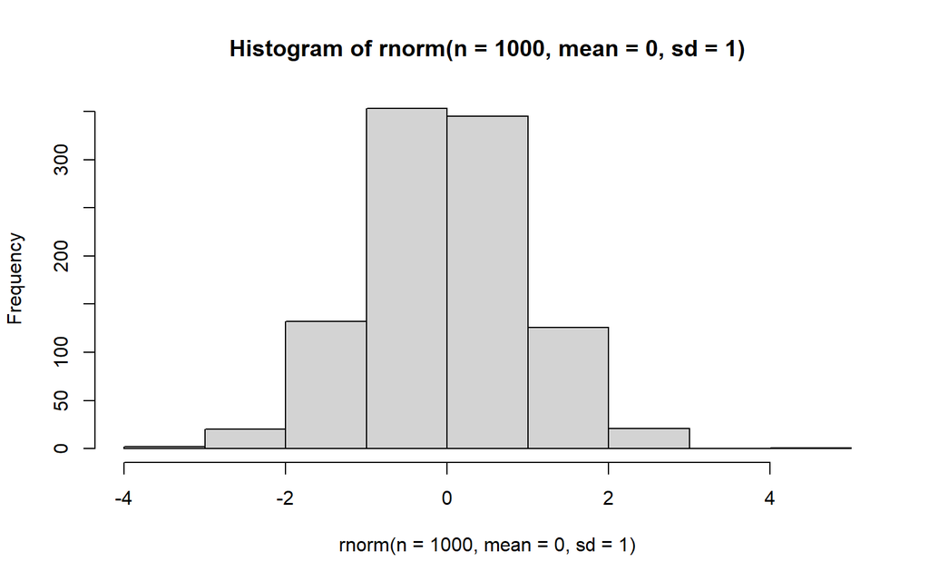

```r
hist(rnorm(n=1000, mean=0, sd=1))  # Histograma dos números gerados
```

### Ajuda para comandos

```r
?rnorm
```

```yaml
rnorm(n, mean = 0, sd = 1)

n: number of observations. If length(n) > 1, the length is taken to be the number required.
mean: vector of means.
sd: vector of standard deviations.
```

- Note acima em “Usage” que já há valores pré-definidos para `mean = 0` e `sd = 1`. Portanto, se você só informar o `n`, a função irá funcionar, considerando os valores pré-definidos para os demais argumentos.
- É possível escrever o código sem os nomes dos argumentos, mas devem ser inseridos na mesma ordem do descrito na Ajuda.

```r
rnorm(10, 0, 1)
```

- Também podemos trocar a ordem explicitando o nome do argumento (NÃO RECOMENDADO)

```r
rnorm(mean=0, n=10, sd=1)
```

## Pacotes do R

- Pacotes são coleções de funções, dados e códigos escritos por outras pessoas
- Por ser um software *open source*, o R possui muitos pacotes disponibilizados pela internet e muitos economistas (principalmente econometristas) já desenvolvem e disponibilizam pacotes com as implementações de seus novos métodos.
- A instalação de um pacote só precisa ser feita uma única vez.
- No entanto, caso você atualize uma nova versão do R, é necessário instalar novamente todos os pacotes.
- Os pacotes podem ser obtidos em bibliotecas (*libraries*), como CRAN, e de indivíduos (normalmente disponibilizados no GitHub)
- O CRAN é administrado e, como existe uma curadoria para inserção e manutenção de pacotes, garante qualidade dos pacotes disponibilizados
- Tome cuidado com pacotes disponibilizados por individuos! É possível executar, dentro do R, códigos para criar e apagar arquivos, por exemplo.

### Instalação via CRAN

> quadrante inferior/direito > Packages > Install > (Nomes dos pacotes)

```r
install.packages("ggplot2") # Pacote para criar graficos
```

### Instalação via GitHub

- Primeiro, é necessário instalar o pacote `devtools`

```r
install.packages("devtools")
```

- Depois, é preciso obter o nome do author (do GitHub) e nome do pacote. Como exemplo, iremos baixar o pacote `dplyr` do autor `hadley` (este pacote, na realidade, pode ser baixado direto do CRAN).
- Para executar uma função de um pacote, podemos usar `<pacote>::<funcao>`

```r
devtools::install_github("hadley/dplyr")
```

- Ou é possível carregar o pacote no ambiente e, depois, chamar a função do pacote carregado

```r
library(devtools)
install_github("hadley/dplyr")
```

- No pacote `dplyr`, há uma base de dados chamada `starwars`.

```r
starwars # Erro
```

- Para ser carregada, precisamos usar a estrutura `<pacote>::<funcao>` ou carregar o pacote inteiro usando `library(dplyr)`

```r
# <pacote>::<funcao>
dplyr::starwars # do pacote dplyr
```

```
## # A tibble: 87 × 14
##    name        height  mass hair_…¹ skin_…² eye_c…³ birth…⁴ sex   gender homew…⁵
##    <chr>        <int> <dbl> <chr>   <chr>   <chr>     <dbl> <chr> <chr>  <chr>
##  1 Luke Skywa…    172    77 blond   fair    blue       19   male  mascu… Tatooi…
##  2 C-3PO          167    75 <NA>    gold    yellow    112   none  mascu… Tatooi…
##  3 R2-D2           96    32 <NA>    white,… red        33   none  mascu… Naboo
##  4 Darth Vader    202   136 none    white   yellow     41.9 male  mascu… Tatooi…
##  5 Leia Organa    150    49 brown   light   brown      19   fema… femin… Aldera…
##  6 Owen Lars      178   120 brown,… light   blue       52   male  mascu… Tatooi…
##  7 Beru White…    165    75 brown   light   blue       47   fema… femin… Tatooi…
##  8 R5-D4           97    32 <NA>    white,… red        NA   none  mascu… Tatooi…
##  9 Biggs Dark…    183    84 black   light   brown      24   male  mascu… Tatooi…
## 10 Obi-Wan Ke…    182    77 auburn… fair    blue-g…    57   male  mascu… Stewjon
## # … with 77 more rows, 4 more variables: species <chr>, films <list>,
## #   vehicles <list>, starships <list>, and abbreviated variable names
## #   ¹hair_color, ²skin_color, ³eye_color, ⁴birth_year, ⁵homeworld
```

```r
# via library()
library(dplyr)
starwars
```

```
## # A tibble: 87 × 14
##    name        height  mass hair_…¹ skin_…² eye_c…³ birth…⁴ sex   gender homew…⁵
##    <chr>        <int> <dbl> <chr>   <chr>   <chr>     <dbl> <chr> <chr>  <chr>
##  1 Luke Skywa…    172    77 blond   fair    blue       19   male  mascu… Tatooi…
##  2 C-3PO          167    75 <NA>    gold    yellow    112   none  mascu… Tatooi…
##  3 R2-D2           96    32 <NA>    white,… red        33   none  mascu… Naboo
##  4 Darth Vader    202   136 none    white   yellow     41.9 male  mascu… Tatooi…
##  5 Leia Organa    150    49 brown   light   brown      19   fema… femin… Aldera…
##  6 Owen Lars      178   120 brown,… light   blue       52   male  mascu… Tatooi…
##  7 Beru White…    165    75 brown   light   blue       47   fema… femin… Tatooi…
##  8 R5-D4           97    32 <NA>    white,… red        NA   none  mascu… Tatooi…
##  9 Biggs Dark…    183    84 black   light   brown      24   male  mascu… Tatooi…
## 10 Obi-Wan Ke…    182    77 auburn… fair    blue-g…    57   male  mascu… Stewjon
## # … with 77 more rows, 4 more variables: species <chr>, films <list>,
## #   vehicles <list>, starships <list>, and abbreviated variable names
## #   ¹hair_color, ²skin_color, ³eye_color, ⁴birth_year, ⁵homeworld
```

### Atualizando pacotes

> quadrante inferior/direito > Packages > Update > Select All > Install Updates

## Ajuda

- Caso saiba o nome da função, é possível olhar sua documentação escrevendo `?<nome_da_funcao>`:

```r
?rnorm # caso seja função base do R ou o pacote já esteja carregado no R
?dplyr::select # caso o pacote não esteja carregado (mas esteja instalado)
```

- Caso saiba o nome do pacote, em alguns casos funciona `?<nome_do_pacote>`, mas o ideal é buscar sua documentação no CRAN (diretamente no site ou via Google)
  - Por exemplo, podemos acessar a página do [pacote `dplyr` no CRAN](https://cran.r-project.org/web/packages/dplyr/index.html):

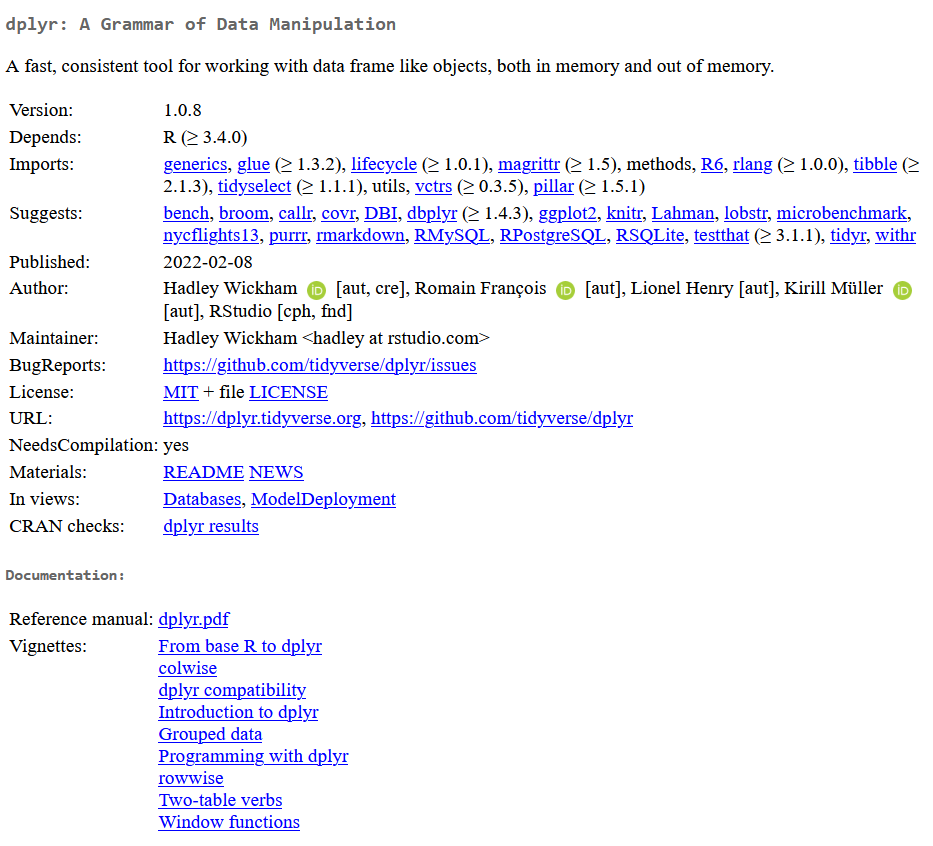

  - Nela é possível ver a partir de qual versão do R funciona, os pacotes necessários para o seu funcionamento (Imports), os autores e sites.
  - Em Documentação, é possível ver o seu ‘Reference manual’ onde são expostos o objetivo do pacotes e as funções, incluindo explicações de seu funcionamento.
  - Além disso, pode ser interessante ver aplicações do pacote e suas funções nas ‘vignettes’. Normalmente são expostas de maneira que podem ser replicadas no seu computador, o que acaba auxiliando na sua aplicação (verificar estrutura de base de dados necessária, sintaxes, etc.). Também pode ser acessada diretamente do R usando a função `browseVignettes()`:

  ```r
  browseVignettes("dplyr") # Abrirá uma página com vignettes no seu navegador
  ```

- Caso não saiba quais funções/pacotes são utilizados para resolver um problema, muitas vezes é possível encontrar a solução no Google utilizando palavras-chave (preferencialmente em inglês) junto de “R”.

[figure not shown]

  - Além de sites especializados em R e vídeos com exemplos de aplicações, é comum aparecer questões no site Stack Overflow (ou em Cross Validated, pertencente ao mesmo grupo) que é o site mais utilizado por programadores em diversas linguagens para esclarecer dúvidas.
  - Por R ser uma linguagem open source, há muitos usuários e, portanto, é comum achar perguntas/respostas que já solucionam o seu problema. Eventualmente, você pode fazer a sua pergunta, caso não encontre uma satisfatória.

[figure not shown]

# Operações e Objetos no R

## Operações básicas

```r
# Soma
1 + 1
```

```
## [1] 2
```

```r
# Subtração
2 - 3
```

```
## [1] -1
```

```r
# Multiplicação
2 * 3
```

```
## [1] 6
```

```r
# Divisão
6 / 4
```

```
## [1] 1.5
```

```r
# Divisão Inteira
6 %/% 4
```

```
## [1] 1
```

```r
# Resto da Divisão
6 %% 4
```

```
## [1] 2
```

```r
# Potenciação
2 ^ 3
```

```
## [1] 8
```

```r
8 ^ (1 / 3)
```

```
## [1] 2
```

## Objetos no R

- [Data types, R objects and attributes (John Hopkins/Coursera)](https://www.coursera.org/learn/r-programming/lecture/OS8hs/data-types-r-objects-and-attributes)

Para criar um objeto, atribuímos algo (neste caso, um valor) a um nome por meio do operador de atribuição `<-` ou `=`:

```r
obj1 <- 5
obj2 = 5 + 2
```

Note que ambos objetos foram criados e aparecem no quadrante superior/direito (*Environment*). Agora, podemos imprimir os seus valores executando o nome do objeto

```r
obj1
```

```
## [1] 5
```

ou imprimindo explicitamente por meio da função `print()`:

```r
print(obj2)
```

```
## [1] 7
```

Note que, podemos alterar um objeto atribuindo algo novo a ele:

```r
obj1 = obj2
obj1
```

```
## [1] 7
```

Uma forma bastante utilizada para alteração de valor de um objeto é utilizando o próprio valor de objeto como base:

```r
obj1 = obj1 + 3
obj1
```

```
## [1] 10
```

> Isto será especialmente relevante quando trabalharmos com repetições/loops.

É possível visualizar o tipo de objeto usando a função `class()`:

```r
class(obj1)
```

```
## [1] "numeric"
```

Logo, `obj1` é um número real. Há 5 tipos de classes de objetos “atômicos” (que contêm apenas 1 valor):

- `character`: texto
- `numeric`: número real
- `integer`: número inteiro
- `complex`: número complexo
- `logical`: verdadeiro/falso (1 ou 0)

```r
num_real = 3
class(num_real)
```

```
## [1] "numeric"
```

```r
num_inteiro = 3L # para número inteiro, usar sufixo L
class(num_inteiro)
```

```
## [1] "integer"
```

```r
texto = "Oi"
print(texto)
```

```
## [1] "Oi"
```

```r
class(texto)
```

```
## [1] "character"
```

```r
boolean = 2>1
print(boolean)
```

```
## [1] TRUE
```

```r
class(boolean)
```

```
## [1] "logical"
```

```r
boolean2 = T # poderia escrever TRUE
print(boolean2)
```

```
## [1] TRUE
```

```r
boolean3 = F # poderia escrever FALSE
print(boolean3)
```

```
## [1] FALSE
```

### Expressões lógicas/booleanas

São expressões que retornam o valor Verdadeiro ou Falso:

```r
class(TRUE)
```

```
## [1] "logical"
```

```r
class(FALSE)
```

```
## [1] "logical"
```

```r
T + F + T + F + F # soma de 1's (TRUE) e 0's (FALSE)
```

```
## [1] 2
```

```r
2 < 20
```

```
## [1] TRUE
```

```r
19 >= 19
```

```
## [1] TRUE
```

```r
100 == 10^2
```

```
## [1] TRUE
```

```r
100 != 20*5
```

```
## [1] FALSE
```

É possível escrever expressões compostas utilizando `|` (ou) e `&` (e):

```r
x = 20
x < 0 | x^2 > 100
```

```
## [1] TRUE
```

```r
x < 0 & x^2 > 100
```

```
## [1] FALSE
```

> **Tabela de Precedência de Operadores**
> - Nível 6 - potenciação: `^`
> - Nível 5 - multiplicação: `*`, `/`, `%/%`, `%%`
> - Nível 4 - adição: `+`, `-`
> - Nível 3 - relacional: `==`, `!=`, `<=`, `>=`, `>`, `<`
> - Nível 2 - lógico: `&` (e)
> - Nível 1 - lógico: `|` (ou)

### Vetores

- [Data types - Vectors and lists (John Hopkins/Coursera)](https://www.coursera.org/learn/r-programming/lecture/wkAHm/data-types-vectors-and-lists)

Depois das 5 classes de objetos apresentadas acima, as mais básicas são os vetores e as listas, que possuem mais de um elemento dentro do objeto. Um vetor necessariamente exige que os elementos sejam da mesma classe. Podemos criar um vetor usando a função `c()` e incluindo os valores separados por `,`:

```r
x = c(0.5, 0.6) # numeric
x = c(TRUE, FALSE) # logical
x = c("a", "b", "c") # character
x = 9:12 # integer (é igual a c(9, 10, 11, 12))
x = c(1+0i, 2+4i) # complex
```

Se utilizarmos a função `c()` com elementos de classes diferentes, o R transforma a classe do objeto para o “mais geral”:

```r
y = c(1.7, "a") # (numeric, character) -> character
class(y)
```

```
## [1] "character"
```

```r
y = c(FALSE, 0.75) # (logical, numeric) -> numeric
class(y)
```

```
## [1] "numeric"
```

```r
y = c("a", TRUE) # (character, logical) -> character
class(y)
```

```
## [1] "character"
```

> **Note que**:

> character $>$ complex $>$ numeric $>$ integer $>$ logical

Também podemos forçar a mudança de classe de objeto para a classe “menos geral”, o que acaba transformando:

- os elementos “mais gerais” em missing values (NA’s),

```r
as.numeric(c(1.7, "a")) # (numeric, character)
```

```
## [1] 1.7  NA
```

```r
as.logical(c("a", TRUE)) # (character, logical)
```

```
## [1]   NA TRUE
```

- [exceção] de *character* com número (por exemplo, “9”) para *numeric*: torna-se *numeric*

```r
as.numeric(c(1.7, "9")) # (numeric, character número)
```

```
## [1] 1.7 9.0
```

- [exceção] de *numeric* diferente de zero para *logical*: torna-se TRUE
- [exceção] de *numeric* igual a zero para *logical*: torna-se FALSE

```r
as.logical(c(FALSE, 0.75, -10)) # (logical, numeric > 0, numeric < 0)
```

```
## [1] FALSE  TRUE  TRUE
```

```r
as.logical(c(TRUE, 0)) # (logical, numeric zero)
```

```
## [1]  TRUE FALSE
```

- [exceção] de *character* lógico (“TRUE”, “T”, “FALSE”, “F”) para *logical*: torna-se *logical* (“0” e “1” tornam-se NA)

```r
as.logical(c("T", "FALSE", "1", TRUE)) # (character TRUE/FALSE, logical)
```

```
## [1]  TRUE FALSE    NA  TRUE
```

#### Construção de vetor de sequência

- Uma forma interessante de construir um vetor numérico com uma sequência é utilizando a função `seq()`

```yaml
seq(from = 1, to = 1, by = ((to - from)/(length.out - 1)),
    length.out = NULL, ...)

from, to: the starting and (maximal) end values of the sequence. Of length 1 unless just from is supplied as an unnamed argument.
by: number, increment of the sequence.
length.out: desired length of the sequence. A non-negative number, which for seq and seq.int will be rounded up if fractional.
```

- Note que todos argumentos já possuem valores pré-definidos, então podemos montar sequências de maneiras distintas.
- Considerando o preenchimento dos argumentos `from` e `to`, podemos:
  - definir `by` para dar um valor de quanto varia entre um elemento e outro, ou
  - definir `length.out` (ou simplesmente `length`) para informar a quantidade de elementos que terá na sequência

```r
seq(from=0, to=10, by=2)
```

```
## [1]  0  2  4  6  8 10
```

```r
seq(from=0, to=10, length=5)
```

```
## [1]  0.0  2.5  5.0  7.5 10.0
```

#### Construção de vetor com elementos repetidos

- Podemos construir vetores com elementos repetidos usando a função `rep()`

```yaml
rep(x, times)

x: a vector (of any mode including a list) or a factor or (for rep only) a POSIXct or POSIXlt or Date object.
```

```r
rep(0, 10) # repetição de 10 zeros
```

```
##  [1] 0 0 0 0 0 0 0 0 0 0
```

```r
rep(c("a", "b"), 2) # repetição do vetor c("a", "b")
```

```
## [1] "a" "b" "a" "b"
```

### Matrizes

Matrizes são vetores (e, portanto, possuem elementos de mesma classe) com atributo de *dimensão* (nº linhas por nº colunas). Uma matriz pode ser criada usando a função `matrix()`:

```yaml
matrix(data = NA, nrow = 1, ncol = 1, byrow = FALSE, ...)

data: an optional data vector (including a list or expression vector). Non-atomic classed R objects are coerced by as.vector and all attributes discarded.
nrow: the desired number of rows.
ncol: the desired number of columns.
byrow: logical. If FALSE (the default) the matrix is filled by columns, otherwise the matrix is filled by rows.
```

```r
m = matrix(nrow=2, ncol=3)
m
```

```
##      [,1] [,2] [,3]
## [1,]   NA   NA   NA
## [2,]   NA   NA   NA
```

É possível construir uma matriz “preenchida” informando os seus (nº linhas $\times$ nº colunas) valores por meio de um vetor. Os elementos deste vetor preenchem primeiro todas linhas de uma coluna para, depois, preencher a próxima coluna (*column-wise*):

```r
m = matrix(1:6, nrow=2, ncol=3)
m
```

```
##      [,1] [,2] [,3]
## [1,]    1    3    5
## [2,]    2    4    6
```

Outra maneira de criar matrizes é juntando vetores em colunas (*column-binding*) ou em linhas (*row-binding*), usando as funções `cbind()` e `rbind()`, respectivamente:

```yaml
cbind(...)
rbind(...)

... : (generalized) vectors or matrices. These can be given as named arguments. Other R objects may be coerced as appropriate, or S4 methods may be used: see sections ‘Details’ and ‘Value’. (For the "data.frame" method of cbind these can be further arguments to data.frame such as stringsAsFactors.)
```

```r
x = 1:3
y = 10:12

cbind(x, y)
```

```
##      x  y
## [1,] 1 10
## [2,] 2 11
## [3,] 3 12
```

```r
rbind(x, y)
```

```
##   [,1] [,2] [,3]
## x    1    2    3
## y   10   11   12
```

### Listas

Já uma lista permite que os valores pertençam a classes distintas, inclusive podendo conter um vetor como elemento. Ela pode ser criada por meio da função `list()`:

```r
x = list(1, "a", TRUE, 1+4i, c(0.5, 0.6))
x
```

```
## [[1]]
## [1] 1
##
## [[2]]
## [1] "a"
##
## [[3]]
## [1] TRUE
##
## [[4]]
## [1] 1+4i
##
## [[5]]
## [1] 0.5 0.6
```

```r
class(x)
```

```
## [1] "list"
```

### Data frames

- [Data types - Data frames (John Hopkins/Coursera)](https://www.coursera.org/learn/r-programming/lecture/kz1Lh/data-types-data-frames)
- É um tipo especial de lista, em que cada elemento da lista possui o mesmo tamanho
- Cada elemento da lista pode ser entendida como uma coluna de uma base de dados
- Diferente de matrizes, cada elemento de um *data frame* pode ser de uma classe diferente
- Normalmente é criada automaticamente ao carregarmos uma base de dados em .txt ou .csv via `read.table()` ou `read.csv()`
- Mas também pode ser criada manualmente via `data.frame()`

```yaml
data.frame(..., stringsAsFactors = FALSE)

... : these arguments are of either the form value or tag = value. Component names are created based on the tag (if present) or the deparsed argument itself.
stringsAsFactors: logical: should character vectors be converted to factors?.
```

```r
x = data.frame(foo=1:4, bar=c(T, T, F, F))
x
```

```
##   foo   bar
## 1   1  TRUE
## 2   2  TRUE
## 3   3 FALSE
## 4   4 FALSE
```

```r
nrow(x) # Número de linhas de x
```

```
## [1] 4
```

```r
ncol(x) # Número de colunas de x
```

```
## [1] 2
```

#### Importando data frames

- [Reading tabular data (John Hopkins/Coursera)](https://www.coursera.org/learn/r-programming/lecture/bQ5B9/reading-tabular-data)
- Para leitura de base de dados, as funções mais utilizadas são `read.table()` e `read.csv()`
- O `read.table()` tem o seguinte argumentos (que também podem ser visto nas demais funções de leitura de base de dados):
  - `file`: caminho/endereço do arquivo, incluindo a sua extensão
  - `header`: `TRUE` ou `FALSE` indicando se a 1ª linha da base de dados é um cabeçalho
  - `sep`: indica como as colunas são separadas
  - `stringAsFactors`: `TRUE` ou `FALSE` se as variáveis de texto devem ser transformadas em *factors*.

  ```r
  data_txt = read.table("mtcars.txt") # também lê .csv
  data_csv = read.csv("mtcars.csv")
  ```

- Caso queira testar, faça download das bases: mtcars.txt e mtcars.csv
- Note que, caso você não tenha definido o diretório de trabalho, é necessário informar o caminho/endereço inteiro do arquivo que você quer importar:

```r
data = read.table("C:/Users/Fabio/OneDrive/FEA-RP/mtcars.csv")
```

- `read.csv()` é igual ao `read.table()`, mas considera como padrão que o separador de colunas é a vírgula (`sep = ","`)
- Para gravar uma base de dados, utilizamos as funções `write.csv()` e `write.table()`, nas quais informamos um data frame e o nome do arquivo (junto de sua extensão).

#### Importando em outros formatos

- Para abrir arquivos em Excel, nos formatos .xls e xlsx, é necessário utilizar o [pacote `xlsx`](https://cran.r-project.org/web/packages/xlsx/xlsx.pdf)

```r
read.xlsx("mtcars.xlsx", sheetIndex=1) # Lendo a 1ª aba do arquivo Excel
```

- Caso queira testar, faça download da base mtcars.xlsx
- Para abrir arquivos de SPSS, Stata e SAS, é necessário utilizar o pacote `haven` e, respectivamente, as funções `read_spss()`, `read_dta()` e `read_sas()`

> Note que no padrão do R, o separador decimal é o ponto (`.`), enquanto no padrão brasileiro usa-se vírgula.

> Isso pode gerar importação equivocada dos valores, caso o .csv ou o .xlsx tenham sido gerados no padrão brasileiro.

> Para contornar este problema, utilize as funções de importação `read.csv2()` e `read.xlsx2()` para que os dados sejam lidos a partir do padrão brasileiro e os dados sejam importados corretamente Caso queira testar, faça download das bases: mtcars_br.csv e mtcars_br.xlsx

## Subconjuntos de objetos

- [Subsetting - Basics (John Hopkins/Coursera)](https://www.coursera.org/learn/r-programming/lecture/JDoLX/subsetting-basics)
- Há 3 operadores básicos para extrair subconjuntos de objetos no R:
  - `[]`: retorna um “sub-objeto” da mesma classe do objeto original
  - `[[]]`: usado para extrair elementos de uma lista ou data frame, em que o “sub-objeto” não é necessariamente da mesma classe do objeto original
  - `$`: usado para extrair elemento de uma lista ou data frame pelo nome

### Subconjunto de vetores

```r
x = c(1, 2, 3, 3, 4, 1)
x[1] # extraindo o 1º elemento de x
```

```
## [1] 1
```

```r
x[1:4] # extraindo do 1º ao 4º elemento de x
```

```
## [1] 1 2 3 3
```

- Note que, ao fazer uma expressão lógica com um vetor, obtemos um *vetor lógico*

```r
x > 1
```

```
## [1] FALSE  TRUE  TRUE  TRUE  TRUE FALSE
```

- Usando o operador `[]`, podemos extrair um subconjunto do vetor `x` usando uma condição. Por exemplo, vamos extrair apenas valores maiores do que 1:

```r
x[x > 1]
```

```
## [1] 2 3 3 4
```

```r
x[c(F, T, T, T, T, F)] # Equivalente ao x[x > 1] - Extrair apenas TRUE's
```

```
## [1] 2 3 3 4
```

### Subconjunto de listas

- [Subsetting - Lists (John Hopkins/Coursera)](https://www.coursera.org/learn/r-programming/lecture/hVKHm/subsetting-lists)
- Note que, diferente do vetor, para acessar um valor/elemento de uma lista é necessário utilizar `[[]]` com o número da posição do elemento da lista

```r
x = list(foo=1:4, bar=0.6)
x
```

```
## $foo
## [1] 1 2 3 4
##
## $bar
## [1] 0.6
```

```r
x[1] # retorna a lista foo
```

```
## $foo
## [1] 1 2 3 4
```

```r
class(x[1])
```

```
## [1] "list"
```

```r
x[[1]] # retorna o vetor foo de classe numeric
```

```
## [1] 1 2 3 4
```

```r
class(x[[1]])
```

```
## [1] "integer"
```

- Se quiser acessar um elemento dentro deste elemento da lista, precisa ser seguido por `[]`

```r
x[[1]][2]
```

```
## [1] 2
```

```r
x[[2]][1]
```

```
## [1] 0.6
```

- Também podemos usar o nome para extrair um subconjunto do objeto

```r
x[["foo"]]
```

```
## [1] 1 2 3 4
```

```r
x$foo
```

```
## [1] 1 2 3 4
```

### Subconjunto de matrizes e de data frames

- [Subsetting - Matrices (John Hopkins/Coursera)](https://www.coursera.org/learn/r-programming/lecture/4gSc1/subsetting-matrices)
- Para extrair um pedaço de uma matriz ou de um data frame, indicamos as linhas e as colunas dentro do operador `[]`

```r
x = matrix(1:6, 2, 3)
x
```

```
##      [,1] [,2] [,3]
## [1,]    1    3    5
## [2,]    2    4    6
```

```r
x[1, 2] # linha 1 e coluna 2 da matriz x
```

```
## [1] 3
```

```r
x[1:2, 2:3] # linha 1 e colunas 2 e 3 da matriz x
```

```
##      [,1] [,2]
## [1,]    3    5
## [2,]    4    6
```

- É possível selecionar linhas/colunas usando um vetor lógico (`TRUE`’s e `FALSE`’s) de mesmo comprimento da dimensão:

```r
x[, c(F, T, T)] # vet. lógico selecionando as 2 últimas colunas
```

```
##      [,1] [,2]
## [1,]    3    5
## [2,]    4    6
```

- Podemos selecionar linhas ou colunas inteiras ao não informar os índices:

```r
x[1, ] # linha 1 e todas colunas
```

```
## [1] 1 3 5
```

```r
x[, 2] # todas linhas e coluna 2
```

```
## [1] 3 4
```

- Note que, quando o subconjunto é um valor único ou um vetor, o objeto retornado deixa de ser uma matriz. Podemos forçar a se manter como matriz usando o argumento `drop= FALSE`

```r
x[1, 2, drop = FALSE]
```

```
##      [,1]
## [1,]    3
```

### Removendo valores ausentes (*missing values* - `NA`)

- [Subsetting - Removing missing values (John Hopkins/Coursera)](https://www.coursera.org/learn/r-programming/lecture/Qy8bH/subsetting-removing-missing-values)
- Remover dados faltantes é uma ação comum quando manipulamos bases de dados
- Para verificar quais dados são `NA`, usa-se a função `is.na()`

```r
x = c(1, 2, NA, 4, NA, NA)
is.na(x)
```

```
## [1] FALSE FALSE  TRUE FALSE  TRUE  TRUE
```

```r
sum(is.na(x)) # qtd de missing values
```

```
## [1] 3
```

- Relembre que o operador `!` nega uma expressão e, portanto, `!is.na()` nos resulta os elementos que **não** são ausentes

```r
x[ !is.na(x) ]
```

```
## [1] 1 2 4
```

## Operações vetoriais/matriciais

- [Vectorized operations (John Hopkins/Coursera)](https://www.coursera.org/learn/r-programming/lecture/nobfZ/vectorized-operations)
- Ao utilizar as operações matemáticas convencionais em vetores, cada elemento é operacionalizado com o elemento na mesma posição do outro vetor

```r
x = 1:4
y = 6:9

x + y # soma de cada elemento na mesma posição
```

```
## [1]  7  9 11 13
```

```r
x + 2 # soma de de cada elemento com um mesmo escalar
```

```
## [1] 3 4 5 6
```

```r
x * y # multiplicação de cada elemento na mesma posição
```

```
## [1]  6 14 24 36
```

```r
x / y # divisão de cada elemento na mesma posição
```

```
## [1] 0.1666667 0.2857143 0.3750000 0.4444444
```

- Para fazer o produto vetorial usa-se `%*%`. Por padrão, o R considera que o 1º vetor é um vetor-linha e o 2º é um vetor-coluna.

```r
# Operações vetoriais
x %*% y # x vetor-linha / y vetor-coluna
```

```
##      [,1]
## [1,]   80
```

```r
x %*% t(y) # x vetor-coluna / y vetor-linha (só altera o segundo)
```

```
##      [,1] [,2] [,3] [,4]
## [1,]    6    7    8    9
## [2,]   12   14   16   18
## [3,]   18   21   24   27
## [4,]   24   28   32   36
```

- Também pode-se “forçar” um vetor em linha ou em coluna via função `matrix()`.

```r
# Transformando vetores em objetos matriz
x_col = matrix(x, ncol=1) # vetor-coluna
x_col
```

```
##      [,1]
## [1,]    1
## [2,]    2
## [3,]    3
## [4,]    4
```

```r
y_lin = matrix(y, nrow=1)
y_lin
```

```
##      [,1] [,2] [,3] [,4]
## [1,]    6    7    8    9
```

```r
# Operações vetoriais
x_col %*% y_lin # x vetor-linha / y vetor-coluna
```

```
##      [,1] [,2] [,3] [,4]
## [1,]    6    7    8    9
## [2,]   12   14   16   18
## [3,]   18   21   24   27
## [4,]   24   28   32   36
```

```r
t(x_col) %*% t(y_lin) # x vetor-linha / y vetor-coluna
```

```
##      [,1]
## [1,]   80
```

- O mesmo é válido para matrizes:

```r
x = matrix(1:4, nrow=2, ncol=2)
x
```

```
##      [,1] [,2]
## [1,]    1    3
## [2,]    2    4
```

```r
y = matrix(rep(10, 4), nrow=2, ncol=2)
y
```

```
##      [,1] [,2]
## [1,]   10   10
## [2,]   10   10
```

```r
x + y # Soma de elementos na mesma posição
```

```
##      [,1] [,2]
## [1,]   11   13
## [2,]   12   14
```

```r
x + 2 # Soma de cada elemento da matriz com um mesmo escalar
```

```
##      [,1] [,2]
## [1,]    3    5
## [2,]    4    6
```

```r
x * y # Multiplicação de elementos na mesma posição
```

```
##      [,1] [,2]
## [1,]   10   30
## [2,]   20   40
```

```r
x %*% y # Multplicação matricial
```

```
##      [,1] [,2]
## [1,]   40   40
## [2,]   60   60
```

## Estatísticas básicas em vetores e matrizes

- **Valores Absolutos**: `abs()`

```r
x = c(1, 4, -5, 2, 8, -2, 4, 7, 8, 0, 2, 3, -5, 7, 4, -4, 2, 5, 2, -3)
x
```

```
##  [1]  1  4 -5  2  8 -2  4  7  8  0  2  3 -5  7  4 -4  2  5  2 -3
```

```r
abs(x)
```

```
##  [1] 1 4 5 2 8 2 4 7 8 0 2 3 5 7 4 4 2 5 2 3
```

- **Soma**: `sum(..., na.rm = FALSE)`

```r
sum(x)
```

```
## [1] 40
```

- **Média**: `mean(x, trim = 0, na.rm = FALSE, ...)`

```r
mean(x)
```

```
## [1] 2
```

- **Desvio Padrão**: `sd(x, na.rm = FALSE)`

```r
sd(x)
```

```
## [1] 4.129483
```

- **Quantis**: `quantile(x, probs = seq(0, 1, 0.25), na.rm = FALSE, ...)`

```r
# Mínimo, 1º Quartil, Mediana, 3º Quartil e Máximo
quantile(x, probs=c(0, .25, .5, .75, 1))
```

```
##    0%   25%   50%   75%  100%
## -5.00 -0.50  2.00  4.25  8.00
```

- **Máximo** e **Mínimo**: `max(..., na.rm = FALSE)` e `min(..., na.rm = FALSE)`

```r
# Mínimo, 1º Quartil, Mediana, 3º Quartil e Máximo
max(x) # Valor máximo
```

```
## [1] 8
```

```r
min(x) # Valor mínimo
```

```
## [1] -5
```

- A obtenção dos valores máximos e mínimos também poderia ser feita usando as funções `which.max()` e `which.min()`, que retornam **o índice do 1º elemento** de valor máximo/mínimo a partir de um **vetor de números**:

```r
which.max(x) # 1º índice de valor máximo
```

```
## [1] 5
```

```r
which.min(x) # 1º índice de valor mínimo
```

```
## [1] 3
```

```r
x[which.max(x)] # extraindo o valor máximo do vetor x
```

```
## [1] 8
```

- Para obter os índices de todos os elementos de valor máximo/mínimo, precisamos usar a função `which()` que tem como argumento um **vetor lógico** (de `TRUE`’s e `FALSE`’s) como input, e gera um vetor de índices:

```yaml
which(x, ...)

x: a logical vector or array. NAs are allowed and omitted (treated as if FALSE).
```

```r
x == max(x) # vetor lógico (TRUE's são os máximos)
```

```
##  [1] FALSE FALSE FALSE FALSE  TRUE FALSE FALSE FALSE  TRUE FALSE FALSE FALSE
## [13] FALSE FALSE FALSE FALSE FALSE FALSE FALSE FALSE
```

```r
which(x == max(x)) # vetor de índices de elementos com valores máximos
```

```
## [1] 5 9
```

```r
x[which(x == max(x))] # valores máximos
```

```
## [1] 8 8
```

- Note que, se houve valores ausentes (`NA`), a função retorna `NA` por padrão. Para excluir os valores ausentes, precisamos definir o argumento `na.rm = TRUE`:

```r
x = c(1, 4, -5, 2, NA, -2, 4, 7, NA, 0, 2, 3, -5, NA, 4, -4, NA, 5, 2, NA)
mean(x) # Sem excluir valores ausentes
```

```
## [1] NA
```

```r
mean(x, na.rm=TRUE) # Excluindo valores ausentes
```

```
## [1] 1.2
```

### Exemplo: Otimização de função univariada

- Queremos encontrar o $x$ que minimiza a função univariada $f(x) = x^2 + 4x - 4$, ou seja,
  $$\text{arg} \min_x
  (x^2 + 4x - 4)$$
- Ver no [Wolfram](https://www.wolframalpha.com/input?i=solve+x%5E2+%2B+4x+-+4+%3D+0)
- Para resolver numericamente, podemos chutar diversos valores de $x$ e pegar o menor valor
- Primeiro, vamos construir um vetor com diversos valores de $x$ no intervalo $[-5, 5]$.

```r
x_grid = seq(-5, 5, length=20)
x_grid
```

```
##  [1] -5.0000000 -4.4736842 -3.9473684 -3.4210526 -2.8947368 -2.3684211
##  [7] -1.8421053 -1.3157895 -0.7894737 -0.2631579  0.2631579  0.7894737
## [13]  1.3157895  1.8421053  2.3684211  2.8947368  3.4210526  3.9473684
## [19]  4.4736842  5.0000000
```

- Agora, vamos calcular o valor de $f(x)$ para cada possível $x$

```r
fx = x_grid^2 + 4*x_grid - 4
```

- Note que cada elemento calculado em `fx_grid` corresponde a um $x$ na mesma posição/índice em `x_grid`

```r
head( cbind(x=x_grid, fx=fx), 6) # mostrando os 6 primeiros valores
```

```
##              x        fx
## [1,] -5.000000  1.000000
## [2,] -4.473684 -1.880886
## [3,] -3.947368 -4.207756
## [4,] -3.421053 -5.980609
## [5,] -2.894737 -7.199446
## [6,] -2.368421 -7.864266
```

- Agora, vamos ver o valor e a *posição* de $x$ que minimiza a função:

```r
min(fx) # f(x) mínimo
```

```
## [1] -7.975069
```

```r
argmin_index = which.min(fx) # índice de x que maximiza
argmin_index
```

```
## [1] 7
```

- Para recuperar o valor de $x$ que minimiza $f(x)$, precisamos usar o índice encontrado para encontrar no vetor `x_grid`:

```r
x_grid[argmin_index]
```

```
## [1] -1.842105
```

- Observe que podemos aumentar a precisão aumentando o número de possíveis valores de $x$ no `x_grid`. Por outro lado, em contas mais complexas, pode elevar muito o tempo de execução do comando.

# Estruturas de controle

- Estruturas de controle no R permitem o controle do fluxo do programa/código.

## Estrutura condicional (`if`/`else`)

- [Control structures - If/Else (John Hopkins/Coursera)](https://www.coursera.org/learn/r-programming/lecture/PDOOA/control-structures-if-else)
- Executa o comando apenas quando uma condição é `TRUE`.

```r
x = 5
if (x > 10) {
    y = 10
    print("caso x > 10")
} else if (x > 0) {
    y = 5
    print("caso 10 >= x > 0")
} else {
    y = 0
    print("caso x >= 0")
}
```

```
## [1] "caso 10 >= x > 0"
```

```r
y
```

```
## [1] 5
```

## Estrutura de repetição/loop (`for`)

- [Control structures - For loops (John Hopkins/Coursera)](https://www.coursera.org/learn/r-programming/lecture/baydC/control-structures-for-loops)
- A repetição usando `for` exige que você insira um vetor e defina um nome para a variável de indicação

```r
for(i in 3:7) {
    print(i)
}
```

```
## [1] 3
## [1] 4
## [1] 5
## [1] 6
## [1] 7
```

- Acima, nomeamos a variável de indicação como `i` e inserimos um vetor de números inteiros entre 3 e 7.
- A cada *iteração* (loop) é atribuído ao `i` um valor do vetor `3:7`, até “acabarem” todos os elementos do vetor
- Sequências são interessantes para incluir em repetições utilizando `for`

```r
sequencia = seq(1, 5, length.out=11)
sequencia
```

```
##  [1] 1.0 1.4 1.8 2.2 2.6 3.0 3.4 3.8 4.2 4.6 5.0
```

```r
for (val in sequencia) {
    print(val^2)
}
```

```
## [1] 1
## [1] 1.96
## [1] 3.24
## [1] 4.84
## [1] 6.76
## [1] 9
## [1] 11.56
## [1] 14.44
## [1] 17.64
## [1] 21.16
## [1] 25
```

## Estrutura de repetição/loop (`while`)

- [Control structures - While loops (John Hopkins/Coursera)](https://www.coursera.org/learn/r-programming/lecture/WWXg6/control-structures-while-loops)
- Diferente do `for`, a repetição via `while` exige que uma variável de indicação já esteja criada previamente antes de entrar no loop
- Isto se dá, pois os loops (inclusive o primeiro) só serão realizados se uma condição for verdadeira
- Note que, por não seguir uma sequência de elemento dentro de um vetor (como no `for`), **é necessário que a variável de indicação seja atualizada a cada iteração para que a repetição não seja feita infinitamente**.
- Um forma comum de executar o `while` é definindo a variável de indicação como um contador, isto é, ir contando a quantidade de loops realizados e parar em uma determinada quantidade

```r
contador = 0

while (contador <= 10) {
    print(contador)
    contador = contador + 1
}
```

```
## [1] 0
## [1] 1
## [1] 2
## [1] 3
## [1] 4
## [1] 5
## [1] 6
## [1] 7
## [1] 8
## [1] 9
## [1] 10
```

- Uma alternativa à variável de indicação que funciona como contador: valor a ser calculado em cada iteração até convergir (chegar a um valor muito pequeno) ou ultrapassar algum valor limite. No exemplo abaixo, a cada loop da variável de indicação `distancia` diminuirá pela metade e irá parar num valor bem próximo de 0 (algum valor menor do que $10^{-3}$)

```r
distancia = 10
tolerancia = 1e-3 # = 1 x 10^(-3) = 0.001

while (distancia > tolerancia) {
    distancia = distancia / 2
}

distancia
```

```
## [1] 0.0006103516
```

#### Exemplo 1: Tabuada

- É comum o uso de uma estrutura de repetição dentro de outra estrutura de repetição (repetições encaixadas).
- Como exemplo, será criada uma matriz vazia e esta será preenchida com a tabela de tabuada

```r
tabuada = matrix(NA, 10, 10)
tabuada
```

```
##       [,1] [,2] [,3] [,4] [,5] [,6] [,7] [,8] [,9] [,10]
##  [1,]   NA   NA   NA   NA   NA   NA   NA   NA   NA    NA
##  [2,]   NA   NA   NA   NA   NA   NA   NA   NA   NA    NA
##  [3,]   NA   NA   NA   NA   NA   NA   NA   NA   NA    NA
##  [4,]   NA   NA   NA   NA   NA   NA   NA   NA   NA    NA
##  [5,]   NA   NA   NA   NA   NA   NA   NA   NA   NA    NA
##  [6,]   NA   NA   NA   NA   NA   NA   NA   NA   NA    NA
##  [7,]   NA   NA   NA   NA   NA   NA   NA   NA   NA    NA
##  [8,]   NA   NA   NA   NA   NA   NA   NA   NA   NA    NA
##  [9,]   NA   NA   NA   NA   NA   NA   NA   NA   NA    NA
## [10,]   NA   NA   NA   NA   NA   NA   NA   NA   NA    NA
```

```r
# Preenchimento da matriz de tabuada
for (linha in 1:10) {
    # Dado um valor de linha, preenche todas colunas
    for (coluna in 1:10) {
        tabuada[linha, coluna] = linha * coluna
    }
    # Terminada todas colunas (de 1 a 10), começa novo loop na próxima linha
}
tabuada
```

```
##       [,1] [,2] [,3] [,4] [,5] [,6] [,7] [,8] [,9] [,10]
##  [1,]    1    2    3    4    5    6    7    8    9    10
##  [2,]    2    4    6    8   10   12   14   16   18    20
##  [3,]    3    6    9   12   15   18   21   24   27    30
##  [4,]    4    8   12   16   20   24   28   32   36    40
##  [5,]    5   10   15   20   25   30   35   40   45    50
##  [6,]    6   12   18   24   30   36   42   48   54    60
##  [7,]    7   14   21   28   35   42   49   56   63    70
##  [8,]    8   16   24   32   40   48   56   64   72    80
##  [9,]    9   18   27   36   45   54   63   72   81    90
## [10,]   10   20   30   40   50   60   70   80   90   100
```

### Exemplo 2: Otimização de função bivariada

- Queremos encontrar o $x$ que minimiza a função univariada $f(x, z) = x^2 + 4z^2 - 4$, ou seja,
  $$\text{arg}
  \min_{x, z} (x^2 + 4z^2 - 4)$$
- Primeiro, vamos criar vetores de possíveis valores de $x$ e $z$.

```r
x_grid = seq(-5, 5, length=11)
z_grid = seq(-6, 6, length=11)
```

- Agora, vamos criar uma matriz em que cada linha representa um valor de $x$ e cada coluna representa um valor de $z$:

```r
# Criando matriz para preencher
fxz = matrix(NA, length(x_grid), length(z_grid))

# Nomeando linhas e colunas
rownames(fxz) = x_grid
colnames(fxz) = z_grid

fxz
```

```
##    -6 -4.8 -3.6 -2.4 -1.2  0 1.2 2.4 3.6 4.8  6
## -5 NA   NA   NA   NA   NA NA  NA  NA  NA  NA NA
## -4 NA   NA   NA   NA   NA NA  NA  NA  NA  NA NA
## -3 NA   NA   NA   NA   NA NA  NA  NA  NA  NA NA
## -2 NA   NA   NA   NA   NA NA  NA  NA  NA  NA NA
## -1 NA   NA   NA   NA   NA NA  NA  NA  NA  NA NA
## 0  NA   NA   NA   NA   NA NA  NA  NA  NA  NA NA
## 1  NA   NA   NA   NA   NA NA  NA  NA  NA  NA NA
## 2  NA   NA   NA   NA   NA NA  NA  NA  NA  NA NA
## 3  NA   NA   NA   NA   NA NA  NA  NA  NA  NA NA
## 4  NA   NA   NA   NA   NA NA  NA  NA  NA  NA NA
## 5  NA   NA   NA   NA   NA NA  NA  NA  NA  NA NA
```

- Agora, vamos preencher cada possível combinação usando a estrutura de repetição dentro de outra repetição.

```r
# Preenchimento da matriz fxz
for (lin_x in 1:length(x_grid)) {
    for (lin_z in 1:length(z_grid)) {
        fxz[lin_x, lin_z] = x_grid[lin_x]^2 + 4*z_grid[lin_z]^2 -4
    }
}
fxz
```

```
##     -6   -4.8  -3.6  -2.4  -1.2  0   1.2   2.4   3.6    4.8   6
## -5 165 113.16 72.84 44.04 26.76 21 26.76 44.04 72.84 113.16 165
## -4 156 104.16 63.84 35.04 17.76 12 17.76 35.04 63.84 104.16 156
## -3 149  97.16 56.84 28.04 10.76  5 10.76 28.04 56.84  97.16 149
## -2 144  92.16 51.84 23.04  5.76  0  5.76 23.04 51.84  92.16 144
## -1 141  89.16 48.84 20.04  2.76 -3  2.76 20.04 48.84  89.16 141
## 0  140  88.16 47.84 19.04  1.76 -4  1.76 19.04 47.84  88.16 140
## 1  141  89.16 48.84 20.04  2.76 -3  2.76 20.04 48.84  89.16 141
## 2  144  92.16 51.84 23.04  5.76  0  5.76 23.04 51.84  92.16 144
## 3  149  97.16 56.84 28.04 10.76  5 10.76 28.04 56.84  97.16 149
## 4  156 104.16 63.84 35.04 17.76 12 17.76 35.04 63.84 104.16 156
## 5  165 113.16 72.84 44.04 26.76 21 26.76 44.04 72.84 113.16 165
```

```r
argmin_index = which(fxz==min(fxz), arr.ind = TRUE)
argmin_index
```

```
##   row col
## 0   6   6
```

```r
argmin_x = x_grid[argmin_index[1]] # aplicando índice de x em x_grid
argmin_z = z_grid[argmin_index[2]] # aplicando índice de z em z_grid

paste0("O par (x = ", argmin_x, ", z = ", argmin_z, ") minimizam a função f(x,z).")
```

```
## [1] "O par (x = 0, z = 0) minimizam a função f(x,z)."
```

# Criando funções

- [Your first R function (John Hopkins/Coursera)](https://www.coursera.org/learn/r-programming/lecture/BM3dR/your-first-r-function)
- Para criar uma função, usamos a função `function(){}`:
  - dentro dos parênteses `()`, nomeamos variáveis arbitrárias (argumentos da função) que serão utilizadas para executar comandos *dentro* da função.
  - dentro das chaves `{}`, usamos as variáveis arbitrárias definidas dentro dos parênteses para fazer cálculos e retornar um output (último valor dentro das chaves)
- Como exemplo, criaremos uma função que pega 2 números como inputs e retorna sua soma

```r
soma = function(a, b) {
    a + b
}
```

- Ao atribuir a função ao objeto `soma` não geramos resultados. Para fazer isso, usamos a função `soma()` inserindo 2 números como inputs:

```r
soma(10, 4)
```

```
## [1] 14
```

- Também pode ser feito com vetores:

```r
soma(1:10, 11:20)
```

```
##  [1] 12 14 16 18 20 22 24 26 28 30
```

- Note que as variáveis arbitrárias `a` e `b` são utilizadas apenas dentro da função

```r
> a
Error: object 'a' not found
```

- Note que podemos inserir um valor padrão para um argumento de função. Como exemplo, criaremos uma função que retorna todos elementos acima de `n` de um vetor dado:

```r
vetor = 1:20
above = function(x, n = 10) {
    x[x > n]
}

above(vetor) # todos acima do valor padrão 10
```

```
##  [1] 11 12 13 14 15 16 17 18 19 20
```

```r
above(vetor, 14) # todos acima de 14
```

```
## [1] 15 16 17 18 19 20
```

# Resumindo dados

## Funções básicas para resumir dados

- [Summarizing data (John Hopkins/Coursera)](https://www.coursera.org/learn/data-cleaning/lecture/e5qVi/summarizing-data)
- Para esta seção, usaremos a base de dados `airquality`, já presente no R.
- Verificaremos o **dimensões** da base com `dim()` e visualizaremos as 6 **primeiras** e **últimas** linhas da base via `head()` e `tail()`, respectivamente.

```r
# data() # lista de base de dados presentes no R

dim(airquality) # Verificar tamanho da base (linhas x colunas)
```

```
## [1] 153   6
```

```r
head(airquality) # Visualizando as 6 primeiras linhas
```

```
##   Ozone Solar.R Wind Temp Month Day
## 1    41     190  7.4   67     5   1
## 2    36     118  8.0   72     5   2
## 3    12     149 12.6   74     5   3
## 4    18     313 11.5   62     5   4
## 5    NA      NA 14.3   56     5   5
## 6    28      NA 14.9   66     5   6
```

```r
tail(airquality) # Visualizando as 6 últimas linhas
```

```
##     Ozone Solar.R Wind Temp Month Day
## 148    14      20 16.6   63     9  25
## 149    30     193  6.9   70     9  26
## 150    NA     145 13.2   77     9  27
## 151    14     191 14.3   75     9  28
## 152    18     131  8.0   76     9  29
## 153    20     223 11.5   68     9  30
```

- Usando `str()`, podemos visualizar a **estrutura** da base:
  - todas a variáveis (colunas),
  - a classe de cada uma delas e
  - algumas de suas observações.

```r
str(airquality)
```

```
## 'data.frame':    153 obs. of  6 variables:
##  $ Ozone  : int  41 36 12 18 NA 28 23 19 8 NA ...
##  $ Solar.R: int  190 118 149 313 NA NA 299 99 19 194 ...
##  $ Wind   : num  7.4 8 12.6 11.5 14.3 14.9 8.6 13.8 20.1 8.6 ...
##  $ Temp   : int  67 72 74 62 56 66 65 59 61 69 ...
##  $ Month  : int  5 5 5 5 5 5 5 5 5 5 ...
##  $ Day    : int  1 2 3 4 5 6 7 8 9 10 ...
```

- Para fazer um **resumo** de todas as variáveis da base, podemos usar a função `summary()` que, para variáveis numéricas, calcula a média e os quartis, e mostra a quantidade de `NA`.

```r
summary(airquality)
```

```
##      Ozone           Solar.R           Wind             Temp
##  Min.   :  1.00   Min.   :  7.0   Min.   : 1.700   Min.   :56.00
##  1st Qu.: 18.00   1st Qu.:115.8   1st Qu.: 7.400   1st Qu.:72.00
##  Median : 31.50   Median :205.0   Median : 9.700   Median :79.00
##  Mean   : 42.13   Mean   :185.9   Mean   : 9.958   Mean   :77.88
##  3rd Qu.: 63.25   3rd Qu.:258.8   3rd Qu.:11.500   3rd Qu.:85.00
##  Max.   :168.00   Max.   :334.0   Max.   :20.700   Max.   :97.00
##  NA's   :37       NA's   :7
##      Month            Day
##  Min.   :5.000   Min.   : 1.0
##  1st Qu.:6.000   1st Qu.: 8.0
##  Median :7.000   Median :16.0
##  Mean   :6.993   Mean   :15.8
##  3rd Qu.:8.000   3rd Qu.:23.0
##  Max.   :9.000   Max.   :31.0
##
```

- Também podemos calcular os **quantis** via `quantile()`

```r
quantile(airquality$Ozone, probs=c(0, .25, .5 , .75, 1), na.rm=TRUE)
```

```
##     0%    25%    50%    75%   100%
##   1.00  18.00  31.50  63.25 168.00
```

- Note que, para variáveis lógicas, de texto ou categóricas (factor), aparecem a contagem de cada categoria/possível valor:

```r
summary(CO2) # base de dados 'Carbon Dioxide Uptake in Grass Plants'
```

```
##      Plant             Type         Treatment       conc          uptake
##  Qn1    : 7   Quebec     :42   nonchilled:42   Min.   :  95   Min.   : 7.70
##  Qn2    : 7   Mississippi:42   chilled   :42   1st Qu.: 175   1st Qu.:17.90
##  Qn3    : 7                                    Median : 350   Median :28.30
##  Qc1    : 7                                    Mean   : 435   Mean   :27.21
##  Qc3    : 7                                    3rd Qu.: 675   3rd Qu.:37.12
##  Qc2    : 7                                    Max.   :1000   Max.   :45.50
##  (Other):42
```

- Para variáveis de texto, pode ser interessante fazer uma **tabela com a contagem** de cada possível categoria de uma variável. Isto é possível por meio da função `table()` e aplicaremos `prop.table(table())` para visualizar em **percentuais**.

```r
table(CO2$Type) # contagem
```

```
##
##      Quebec Mississippi
##          42          42
```

```r
prop.table(table(CO2$Type)) # percentual
```

```
##
##      Quebec Mississippi
##         0.5         0.5
```

- Também podemos incluir mais uma variável em `table()` para visualizar a contagem considerando 2 variáveis:

```r
table(CO2$Type, CO2$Treatment)
```

```
##
##               nonchilled chilled
##   Quebec              21      21
##   Mississippi         21      21
```

## Família de funções *apply*

Veremos uma família de funções *apply* que permitem executar comandos em loop de maneira compacta: - `apply`: aplica uma função sobre as margens (linha ou coluna) de uma matrix/array - `lapply`: loop sobre uma lista e avalia uma função em cada elemento - função auxiliar `split` é útil ao ser utilizada em conjunto da `lapply` - `sapply`: mesmo que o `lapply`, mas simplifica o resultado

### Função `apply()`

- [Loop functions - apply (John Hopkins/Coursera)](https://www.coursera.org/learn/r-programming/lecture/IUUhK/loop-functions-apply)
- Usado para avaliar, por meio de uma função, margens de um array
- Frequentemente é utilizado para aplicar uma função a linhas ou a colunas de uma matriz
- Não é mais rápido do que escrever um loop, mas funciona em uma única linha

```yaml
apply(X, MARGIN, FUN, ...)

X: an array, including a matrix.MARGIN: a vector giving the subscripts which the function will be applied over. E.g., for a matrix 1 indicates rows, 2 indicates columns, c(1, 2) indicates rows and columns. Where X has named dimnames, it can be a character vector selecting dimension names.
FUN: the function to be applied: see ‘Details’. In the case of functions like +, %*%, etc., the function name must be backquoted or quoted.
... : optional arguments to FUN.
```

```r
x = matrix(1:20, 5, 4)
x
```

```
##      [,1] [,2] [,3] [,4]
## [1,]    1    6   11   16
## [2,]    2    7   12   17
## [3,]    3    8   13   18
## [4,]    4    9   14   19
## [5,]    5   10   15   20
```

```r
apply(x, 1, mean) # médias das linhas
```

```
## [1]  8.5  9.5 10.5 11.5 12.5
```

```r
apply(x, 2, mean) # médias das colunas
```

```
## [1]  3  8 13 18
```

- Há funções pré-definidas que aplicam `apply` com soma e com média:
  - `rowSums = apply(x, 1, sum)`
  - `rowMeans = apply(x, 1, mean)`
  - `colSums = apply(x, 2, sum)`
  - `colMeans = apply(x, 2, mean)`
- Podemos, por exemplo, também calcular os quantis de uma matriz usando a função `quantile()`

```r
x = matrix(1:50, 10, 5) # matriz 20x10 - 200 números ~ N(0, 1)
x
```

```
##       [,1] [,2] [,3] [,4] [,5]
##  [1,]    1   11   21   31   41
##  [2,]    2   12   22   32   42
##  [3,]    3   13   23   33   43
##  [4,]    4   14   24   34   44
##  [5,]    5   15   25   35   45
##  [6,]    6   16   26   36   46
##  [7,]    7   17   27   37   47
##  [8,]    8   18   28   38   48
##  [9,]    9   19   29   39   49
## [10,]   10   20   30   40   50
```

```r
apply(x, 2, quantile) # obtendo os quantis de cada coluna
```

```
##       [,1]  [,2]  [,3]  [,4]  [,5]
## 0%    1.00 11.00 21.00 31.00 41.00
## 25%   3.25 13.25 23.25 33.25 43.25
## 50%   5.50 15.50 25.50 35.50 45.50
## 75%   7.75 17.75 27.75 37.75 47.75
## 100% 10.00 20.00 30.00 40.00 50.00
```

- Com também podemos verificar quais são os valores únicos de cada variável em um data frame combinando `apply()` e `unique()`

```r
apply(mtcars, 2, unique)
```

```
## $mpg
##  [1] 21.0 22.8 21.4 18.7 18.1 14.3 24.4 19.2 17.8 16.4 17.3 15.2 10.4 14.7 32.4
## [16] 30.4 33.9 21.5 15.5 13.3 27.3 26.0 15.8 19.7 15.0
##
## $cyl
## [1] 6 4 8
##
## $disp
##  [1] 160.0 108.0 258.0 360.0 225.0 146.7 140.8 167.6 275.8 472.0 460.0 440.0
## [13]  78.7  75.7  71.1 120.1 318.0 304.0 350.0 400.0  79.0 120.3  95.1 351.0
## [25] 145.0 301.0 121.0
##
## $hp
##  [1] 110  93 175 105 245  62  95 123 180 205 215 230  66  52  65  97 150  91 113
## [20] 264 335 109
##
## $drat
##  [1] 3.90 3.85 3.08 3.15 2.76 3.21 3.69 3.92 3.07 2.93 3.00 3.23 4.08 4.93 4.22
## [16] 3.70 3.73 4.43 3.77 3.62 3.54 4.11
##
## $wt
##  [1] 2.620 2.875 2.320 3.215 3.440 3.460 3.570 3.190 3.150 4.070 3.730 3.780
## [13] 5.250 5.424 5.345 2.200 1.615 1.835 2.465 3.520 3.435 3.840 3.845 1.935
## [25] 2.140 1.513 3.170 2.770 2.780
##
## $qsec
##  [1] 16.46 17.02 18.61 19.44 20.22 15.84 20.00 22.90 18.30 18.90 17.40 17.60
## [13] 18.00 17.98 17.82 17.42 19.47 18.52 19.90 20.01 16.87 17.30 15.41 17.05
## [25] 16.70 16.90 14.50 15.50 14.60 18.60
##
## $vs
## [1] 0 1
##
## $am
## [1] 1 0
##
## $gear
## [1] 4 3 5
##
## $carb
## [1] 4 1 2 3 6 8
```

- Podemos verificar o **número de NA’s** em cada coluna usando `apply()` com `sum` (ou também `colSums()`) na base de dados com `is.na()` (transforma a base de dados em TRUE/FALSE se for ou não `NA`)

```r
head( is.na(airquality) ) # 6 primeiras linhas aplicando is.na()
```

```
##      Ozone Solar.R  Wind  Temp Month   Day
## [1,] FALSE   FALSE FALSE FALSE FALSE FALSE
## [2,] FALSE   FALSE FALSE FALSE FALSE FALSE
## [3,] FALSE   FALSE FALSE FALSE FALSE FALSE
## [4,] FALSE   FALSE FALSE FALSE FALSE FALSE
## [5,]  TRUE    TRUE FALSE FALSE FALSE FALSE
## [6,] FALSE    TRUE FALSE FALSE FALSE FALSE
```

```r
apply(is.na(airquality), 2, sum) # somando cada coluna de TRUE/FALSE
```

```
##   Ozone Solar.R    Wind    Temp   Month     Day
##      37       7       0       0       0       0
```

### Função `lapply()`

- [Loop functions - lapply (John Hopkins/Coursera)](https://www.coursera.org/learn/r-programming/lecture/t5iuo/loop-functions-lapply)
- `lapply` usa três argumentos: uma **lista**, o nome de uma função e outros argumentos (incluindo os da função inserida)

```yaml
lapply(X, FUN, ...)

X: a vector (atomic or list) or an expression object. Other objects (including classed objects) will be coerced by base::as.list.
FUN: the function to be applied to each element of X: see ‘Details’. In the case of functions like +, %*%, the function name must be backquoted or quoted.
... : optional arguments to FUN.
```

```r
# Criando uma lista com vetor de dimensões distintas
x = list(a=1:5, b=rnorm(10), c=c(1, 4, 65, 6))
x
```

```
## $a
## [1] 1 2 3 4 5
##
## $b
##  [1] -0.3564357  0.4707686 -0.1252771 -1.3651737  0.4829958 -0.2940269
##  [7] -0.7046485 -0.1294322  0.3276782 -0.7079934
##
## $c
## [1]  1  4 65  6
```

```r
lapply(x, mean) # retorna médias de cada vetor dentro da lista
```

```
## $a
## [1] 3
##
## $b
## [1] -0.2401545
##
## $c
## [1] 19
```

```r
lapply(x, summary) # retorna 6 estatísticas de cada vetor dentro da lista
```

```
## $a
##    Min. 1st Qu.  Median    Mean 3rd Qu.    Max.
##       1       2       3       3       4       5
##
## $b
##    Min. 1st Qu.  Median    Mean 3rd Qu.    Max.
## -1.3652 -0.6176 -0.2117 -0.2402  0.2144  0.4830
##
## $c
##    Min. 1st Qu.  Median    Mean 3rd Qu.    Max.
##    1.00    3.25    5.00   19.00   20.75   65.00
```

```r
class(lapply(x, mean)) # classe do objeto retornado pelo lapply
```

```
## [1] "list"
```

### Função `sapply()`

Similar ao `lapply`, mas `sapply` tenta simplificar o output:

- Se o resultado for uma lista em que todo elemento tem comprimento 1 (tem apenas um elemento também), retorna um vetor

```r
sapply(x, mean) # retorna um vetor
```

```
##          a          b          c
##  3.0000000 -0.2401545 19.0000000
```

- Se o resultado for uma lista em que cada elemento tem mesmo comprimento, retorna uma matriz

```r
sapply(x, summary) # retorna uma matriz
```

```
##         a          b     c
## Min.    1 -1.3651737  1.00
## 1st Qu. 2 -0.6175953  3.25
## Median  3 -0.2117295  5.00
## Mean    3 -0.2401545 19.00
## 3rd Qu. 4  0.2144394 20.75
## Max.    5  0.4829958 65.00
```

# Manipulação de dados

> “Between 30% to 80% of the data analysis task is spent on cleaning and understanding the data.” (Dasu & Johnson, 2003)

## Extração de subconjuntos

- [Subsetting and sorting (John Hopkins/Coursera)](https://www.coursera.org/learn/data-cleaning/lecture/aqd2Y/subsetting-and-sorting)
- Como exemplo, criaremos um *data frame* com três variáveis, em que, para misturar a ordem dos números, usaremos a função `sample()` num vetor de números e também incluiremos alguns valores ausentes `NA`.

```r
set.seed(2022)

# Criando uma base de dados arbitrária
x = data.frame("var1"=sample(1:5), "var2"=sample(6:10), "var3"=sample(11:15))
x
```

```
##   var1 var2 var3
## 1    4    9   13
## 2    3    7   11
## 3    2    8   12
## 4    1   10   15
## 5    5    6   14
```

```r
x$var2[c(1, 3)] = NA
x
```

```
##   var1 var2 var3
## 1    4   NA   13
## 2    3    7   11
## 3    2   NA   12
## 4    1   10   15
## 5    5    6   14
```

- Lembre-se que, para extrair um subconjunto de um data frame, usamos as chaves `[]` indicando vetores de linhas e de colunas (ou também os nomes das colunas).

```r
x[, 1] # Todas linhas e 1ª coluna
```

```
## [1] 4 3 2 1 5
```

```r
x[, "var1"] # Todas linhas e 1ª coluna (usando seu nome)
```

```
## [1] 4 3 2 1 5
```

```r
x[1:2, "var2"] # Linhas 1 e 2, e 2ª coluna (usando seu nome)
```

```
## [1] NA  7
```

- Note que, podemos usar expressões lógicas (vetor com `TRUE` e `FALSE`) para extrair uma parte do data frame. Por exemplo, queremos obter apenas as observações em que a variável 1 seja menor ou igual a 3 **E** (`&`) que a variável 3 seja estritamente maior do que 11:

```r
x$var1 <= 3
```

```
## [1] FALSE  TRUE  TRUE  TRUE FALSE
```

```r
x[x$var1 <= 3,] # Extraindo as linhas de x
```

```
##   var1 var2 var3
## 2    3    7   11
## 3    2   NA   12
## 4    1   10   15
```

```r
x$var1 <= 3 & x$var3 > 11
```

```
## [1] FALSE FALSE  TRUE  TRUE FALSE
```

```r
x[x$var1 <= 3 & x$var3 > 11,] # Extraindo as linhas de x
```

```
##   var1 var2 var3
## 3    2   NA   12
## 4    1   10   15
```

- Poderíamos também obter apenas as observações em que a variável 1 seja menor ou igual a 3 **OU** (`|`) que a variável 3 seja estritamente maior do que 11:

```r
x[x$var1 <= 3 | x$var3 > 11, ]
```

```
##   var1 var2 var3
## 1    4   NA   13
## 2    3    7   11
## 3    2   NA   12
## 4    1   10   15
## 5    5    6   14
```

- Também podemos verificar se determinados valores estão contidos em um vetor específico (equivale `==` com mais de um valor)

```r
x$var1 %in% c(1, 5) # obs em que var1 é igual a 1 ou 5
```

```
## [1] FALSE FALSE FALSE  TRUE  TRUE
```

```r
x[x$var1 %in% c(1, 5), ]
```

```
##   var1 var2 var3
## 4    1   10   15
## 5    5    6   14
```

- Note que, ao escrevermos uma expressão lógica para um vetor que contém valores ausentes, gerará um vetor com `TRUE`, `FALSE` e `NA`

```r
x$var2 > 8
```

```
## [1]    NA FALSE    NA  TRUE FALSE
```

```r
x[x$var2 > 8, ]
```

```
##      var1 var2 var3
## NA     NA   NA   NA
## NA.1   NA   NA   NA
## 4       1   10   15
```

- Para contornar este problema, podemos usar a função `which()` que, ao invés de gerar um vetor de `TRUE`/`FALSE`, retorna um vetor com as posições dos elementos que tornam a expressão lógica verdadeira

```r
which(x$var2 > 8)
```

```
## [1] 4
```

```r
x[which(x$var2 > 8), ]
```

```
##   var1 var2 var3
## 4    1   10   15
```

- Outra forma de contornar os valores ausentes é incluir a condição de não incluir valores ausentes `!is.na()`:

```r
x$var2 > 8 & !is.na(x$var2)
```

```
## [1] FALSE FALSE FALSE  TRUE FALSE
```

```r
x[x$var2 > 8 & !is.na(x$var2), ]
```

```
##   var1 var2 var3
## 4    1   10   15
```

## Ordenação

- Podemos usar a função `sort()` para ordenar um vetor de maneira crescente (padrão) ou decrescente:

```r
sort(x$var1) # ordenando de maneira crescente
```

```
## [1] 1 2 3 4 5
```

```r
sort(x$var1, decreasing=TRUE) # ordenando de maneira decrescente
```

```
## [1] 5 4 3 2 1
```

- Por padrão, o `sort()` retira os valores ausentes. Para mantê-los e deixá-los no final, precisamos usar o argumento `na.last=TRUE`

```r
sort(x$var2) # ordenando e retirando NA
```

```
## [1]  6  7 10
```

```r
sort(x$var2, na.last=TRUE) # ordenando e mantendo NA no final
```

```
## [1]  6  7 10 NA NA
```

- Note que não podemos usar a função `sort()` para ordenar um data frame, pois a função retorna valores e, portanto, não retorna suas posições.

```r
sort(x$var3)
```

```
## [1] 11 12 13 14 15
```

```r
x[sort(x$var3), ] # Retorna erro, pois não há nº de linhas > 5
```

```
##      var1 var2 var3
## NA     NA   NA   NA
## NA.1   NA   NA   NA
## NA.2   NA   NA   NA
## NA.3   NA   NA   NA
## NA.4   NA   NA   NA
```

- Para ordenar data frames, precisamos utilizar a função `order()` que, ao invés de retorar os valores em algum ordem, retorna as suas posições

```r
order(x$var3)
```

```
## [1] 2 3 1 5 4
```

```r
x[order(x$var3), ] # Retorna erro, pois não há nº de linhas > 5
```

```
##   var1 var2 var3
## 2    3    7   11
## 3    2   NA   12
## 1    4   NA   13
## 5    5    6   14
## 4    1   10   15
```

## Inclusão de novas colunas/variáveis

- Para incluir novas variáveis, podemos usar `$<novo_nome_var>` e atribuir um vetor de mesmo tamanho (mesma quantidade de linhas):

```r
x$var4 = rnorm(5)
x
```

```
##   var1 var2 var3        var4
## 1    4   NA   13 -1.16252771
## 2    3    7   11  0.03637665
## 3    2   NA   12  1.04034378
## 4    1   10   15  0.17720563
## 5    5    6   14 -1.09296084
```

- [Algumas transformações comuns de variáveis (John Hopkins/Coursera)](https://www.coursera.org/learn/data-cleaning/lecture/r6VHJ/creating-new-variables)

```r
abs(x$var4) # valor absoluto
```

```
## [1] 1.16252771 0.03637665 1.04034378 0.17720563 1.09296084
```

```r
sqrt(x$var4) # raiz quadrada
```

```
## [1]       NaN 0.1907266 1.0199724 0.4209580       NaN
```

```r
ceiling(x$var4) # valor inteiro acima
```

```
## [1] -1  1  2  1 -1
```

```r
floor(x$var4) # valor inteiro abaixo
```

```
## [1] -2  0  1  0 -2
```

```r
round(x$var4, digits=1) # arredondamento com 1 dígito
```

```
## [1] -1.2  0.0  1.0  0.2 -1.1
```

```r
cos(x$var4) # cosseno
```

```
## [1] 0.3970208 0.9993384 0.5059237 0.9843401 0.4598582
```

```r
sin(x$var4) # seno
```

```
## [1] -0.91780959  0.03636862  0.86257821  0.17627965 -0.88799237
```

```r
log(x$var4) # logaritmo natural
```

```
## [1]         NaN -3.31382832  0.03955122 -1.73044448         NaN
```

```r
log10(x$var4) # logaritmo base 10
```

```
## [1]         NaN -1.43917735  0.01717688 -0.75152249         NaN
```

```r
exp(x$var4) # exponencial
```

```
## [1] 0.3126948 1.0370464 2.8301898 1.1938766 0.3352225
```

## Juntando bases de dados

### Acrescentando colunas e linhas via `cbind()` e `rbind()`

- Uma maneira de juntar o data frame com um vetor de mesmo tamanho é usando `cbind()`

```r
y = rnorm(5)
x = cbind(x, y)
x
```

```
##   var1 var2 var3        var4          y
## 1    4   NA   13 -1.16252771  1.5147431
## 2    3    7   11  0.03637665  2.8275563
## 3    2   NA   12  1.04034378  0.7507876
## 4    1   10   15  0.17720563  0.3521377
## 5    5    6   14 -1.09296084 -0.2394846
```

- Também podemos acrescentar linhas usando `rbind()`, desde que o vetor tenha a quantidade de elementos igual ao número de colunas (ou data frame a ser incluído tenha o mesmo número de colunas)

```r
z = rnorm(5)
x = rbind(x, z)
x
```

```
##        var1       var2       var3        var4           y
## 1  4.000000         NA 13.0000000 -1.16252771  1.51474310
## 2  3.000000  7.0000000 11.0000000  0.03637665  2.82755634
## 3  2.000000         NA 12.0000000  1.04034378  0.75078755
## 4  1.000000 10.0000000 15.0000000  0.17720563  0.35213771
## 5  5.000000  6.0000000 14.0000000 -1.09296084 -0.23948464
## 6 -1.491039  0.1253538  0.7226886 -0.14665985  0.06153939
```

### Mesclando base de dados com `merge()`

- [Merging data (John Hopkins/Coursera)](https://www.coursera.org/learn/data-cleaning/lecture/pVV6K/merging-data)
- Podemos juntar base de dados a partir de uma variável-chave que aparece em ambas bases.
- Como exemplo, utilizaremos duas bases de dados de respostas a perguntas (`solutions`) e de correções feitas por seus pares (`reviews`).

```r
solutions = read.csv("https://raw.githubusercontent.com/jtleek/dataanalysis/master/week2/007summarizingData/data/solutions.csv")
head(solutions)
```

```
##   id problem_id subject_id      start       stop time_left answer
## 1  1        156         29 1304095119 1304095169      2343      B
## 2  2        269         25 1304095119 1304095183      2329      C
## 3  3         34         22 1304095127 1304095146      2366      C
## 4  4         19         23 1304095127 1304095150      2362      D
## 5  5        605         26 1304095127 1304095167      2345      A
## 6  6        384         27 1304095131 1304095270      2242      C
```

```r
reviews = read.csv("https://raw.githubusercontent.com/jtleek/dataanalysis/master/week2/007summarizingData/data/reviews.csv")
head(reviews)
```

```
##   id solution_id reviewer_id      start       stop time_left accept
## 1  1           3          27 1304095698 1304095758      1754      1
## 2  2           4          22 1304095188 1304095206      2306      1
## 3  3           5          28 1304095276 1304095320      2192      1
## 4  4           1          26 1304095267 1304095423      2089      1
## 5  5          10          29 1304095456 1304095469      2043      1
## 6  6           2          29 1304095471 1304095513      1999      1
```

```yaml
merge(x, y, by = intersect(names(x), names(y)),
      by.x = by, by.y = by, all = FALSE, all.x = all, all.y = all,
      sort = TRUE, suffixes = c(".x",".y"), ...)

x, y: data frames, or objects to be coerced to one.
by, by.x, by.y: specifications of the columns used for merging. See ‘Details’.
all: logical; all = L is shorthand for all.x = L and all.y = L, where L is either TRUE or FALSE.
all.x: logical; if TRUE, then extra rows will be added to the output, one for each row in x that has no matching row in y. These rows will have NAs in those columns that are usually filled with values from y. The default is FALSE, so that only rows with data from both x and y are included in the output.
all.y: logical; analogous to all.x.
sort: logical. Should the result be sorted on the by columns?
suffixes: a character vector of length 2 specifying the suffixes to be used for making unique the names of columns in the result which are not used for merging (appearing in by etc).
```

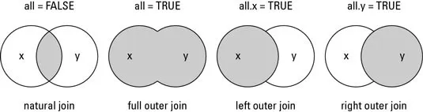

```r
mergedData = merge(reviews, solutions,
                   by.x="solution_id",
                   by.y="id",
                   all=TRUE)
head(mergedData)
```

```
##   solution_id id reviewer_id    start.x     stop.x time_left.x accept
## 1           1  4          26 1304095267 1304095423        2089      1
## 2           2  6          29 1304095471 1304095513        1999      1
## 3           3  1          27 1304095698 1304095758        1754      1
## 4           4  2          22 1304095188 1304095206        2306      1
## 5           5  3          28 1304095276 1304095320        2192      1
## 6           6 16          22 1304095303 1304095471        2041      1
##   problem_id subject_id    start.y     stop.y time_left.y answer
## 1        156         29 1304095119 1304095169        2343      B
## 2        269         25 1304095119 1304095183        2329      C
## 3         34         22 1304095127 1304095146        2366      C
## 4         19         23 1304095127 1304095150        2362      D
## 5        605         26 1304095127 1304095167        2345      A
## 6        384         27 1304095131 1304095270        2242      C
```

- Note que, como há colunas de mesmos nomes, e especificamos que a variável chave era somente o id de solução, então as colunas de nomes iguais foram renomeadas com sufixos `.x` e `.y`, correspondendo às 1ª e 2ª bases inseridas na função `merge()`
- Para verificar as colunas com mesmos nomes em duas bases, podemos usar a função `intersect()` em conjunto com a função `names()`:

```r
intersect( names(solutions), names(reviews) )
```

```
## [1] "id"        "start"     "stop"      "time_left"
```

- Se não especificássemos nenhuma variável-chave, a função `merge()` utilizaria como variável-chave todas as colunas com nomes iguais em ambas bases de dados

```r
wrong = merge(reviews, solutions,
                   all=TRUE)
head(wrong)
```

```
##   id      start       stop time_left solution_id reviewer_id accept problem_id
## 1  1 1304095119 1304095169      2343          NA          NA     NA        156
## 2  1 1304095698 1304095758      1754           3          27      1         NA
## 3  2 1304095119 1304095183      2329          NA          NA     NA        269
## 4  2 1304095188 1304095206      2306           4          22      1         NA
## 5  3 1304095127 1304095146      2366          NA          NA     NA         34
## 6  3 1304095276 1304095320      2192           5          28      1         NA
##   subject_id answer
## 1         29      B
## 2         NA   <NA>
## 3         25      C
## 4         NA   <NA>
## 5         22      C
## 6         NA   <NA>
```

# Manipulação via `dplyr`

- [Vignette - Introduction to *dplyr*](https://cran.r-project.org/web/packages/dplyr/vignettes/dplyr.html)
- O pacote `dplyr` facilita a manipulação dos dados por meio de funções simples e computacionalmente eficientes
- As funções pode, ser organizadas em três categorias:
  - Colunas:
    - `select()`: seleciona (ou retira) as colunas do data frame
    - `rename()`: muda os nomes das colunas
    - `mutate()`: cria ou muda os valores nas colunas
  - Linhas:
    - `filter()`: seleciona linhas de acordo com valores das colunas
    - `arrange()`: organiza a ordem das linhas
  - Grupo de linhas:
    - `summarise()`: colapsa um grupo em uma única linha
- Nesta subseção, continuaremos utilizando a base de dados de Star Wars (`starwars`), utilizada na subseção anterior.
- Você irá notar que, ao usar essas funções, o data frame é transformado em um *tibble* que é um formato mais eficiente para tratar dados tabulares, mas que funciona de forma igual a um data frame.

```r
library("dplyr")
bd_sw = starwars # Dando novo nome para a base starwars
head(bd_sw)
```

```
## # A tibble: 6 × 14
##   name         height  mass hair_…¹ skin_…² eye_c…³ birth…⁴ sex   gender homew…⁵
##   <chr>         <int> <dbl> <chr>   <chr>   <chr>     <dbl> <chr> <chr>  <chr>
## 1 Luke Skywal…    172    77 blond   fair    blue       19   male  mascu… Tatooi…
## 2 C-3PO           167    75 <NA>    gold    yellow    112   none  mascu… Tatooi…
## 3 R2-D2            96    32 <NA>    white,… red        33   none  mascu… Naboo
## 4 Darth Vader     202   136 none    white   yellow     41.9 male  mascu… Tatooi…
## 5 Leia Organa     150    49 brown   light   brown      19   fema… femin… Aldera…
## 6 Owen Lars       178   120 brown,… light   blue       52   male  mascu… Tatooi…
## # … with 4 more variables: species <chr>, films <list>, vehicles <list>,
## #   starships <list>, and abbreviated variable names ¹hair_color, ²skin_color,
## #   ³eye_color, ⁴birth_year, ⁵homeworld
```

## Filtre linhas com `filter()`

- Permite selecionar um subconjunto de linhas de um data frame

```yaml
filter(.data, ...)

.data: A data frame, data frame extension (e.g. a tibble), or a lazy data frame (e.g. from dbplyr or dtplyr).
... : <data-masking> Expressions that return a logical value, and are defined in terms of the variables in .data. If multiple expressions are included, they are combined with the & operator. Only rows for which all conditions evaluate to TRUE are kept.
```

```r
bd_sw1 = filter(bd_sw, species == "Human", height >= 100)
bd_sw1
```

```
## # A tibble: 31 × 14
##    name        height  mass hair_…¹ skin_…² eye_c…³ birth…⁴ sex   gender homew…⁵
##    <chr>        <int> <dbl> <chr>   <chr>   <chr>     <dbl> <chr> <chr>  <chr>
##  1 Luke Skywa…    172    77 blond   fair    blue       19   male  mascu… Tatooi…
##  2 Darth Vader    202   136 none    white   yellow     41.9 male  mascu… Tatooi…
##  3 Leia Organa    150    49 brown   light   brown      19   fema… femin… Aldera…
##  4 Owen Lars      178   120 brown,… light   blue       52   male  mascu… Tatooi…
##  5 Beru White…    165    75 brown   light   blue       47   fema… femin… Tatooi…
##  6 Biggs Dark…    183    84 black   light   brown      24   male  mascu… Tatooi…
##  7 Obi-Wan Ke…    182    77 auburn… fair    blue-g…    57   male  mascu… Stewjon
##  8 Anakin Sky…    188    84 blond   fair    blue       41.9 male  mascu… Tatooi…
##  9 Wilhuff Ta…    180    NA auburn… fair    blue       64   male  mascu… Eriadu
## 10 Han Solo       180    80 brown   fair    brown      29   male  mascu… Corell…
## # … with 21 more rows, 4 more variables: species <chr>, films <list>,
## #   vehicles <list>, starships <list>, and abbreviated variable names
## #   ¹hair_color, ²skin_color, ³eye_color, ⁴birth_year, ⁵homeworld
```

```r
# Equivalente a:
bd_sw[bd_sw$species == "Human" & bd_sw$height >= 100, ]
```

```
## # A tibble: 39 × 14
##    name        height  mass hair_…¹ skin_…² eye_c…³ birth…⁴ sex   gender homew…⁵
##    <chr>        <int> <dbl> <chr>   <chr>   <chr>     <dbl> <chr> <chr>  <chr>
##  1 Luke Skywa…    172    77 blond   fair    blue       19   male  mascu… Tatooi…
##  2 Darth Vader    202   136 none    white   yellow     41.9 male  mascu… Tatooi…
##  3 Leia Organa    150    49 brown   light   brown      19   fema… femin… Aldera…
##  4 Owen Lars      178   120 brown,… light   blue       52   male  mascu… Tatooi…
##  5 Beru White…    165    75 brown   light   blue       47   fema… femin… Tatooi…
##  6 Biggs Dark…    183    84 black   light   brown      24   male  mascu… Tatooi…
##  7 Obi-Wan Ke…    182    77 auburn… fair    blue-g…    57   male  mascu… Stewjon
##  8 Anakin Sky…    188    84 blond   fair    blue       41.9 male  mascu… Tatooi…
##  9 Wilhuff Ta…    180    NA auburn… fair    blue       64   male  mascu… Eriadu
## 10 Han Solo       180    80 brown   fair    brown      29   male  mascu… Corell…
## # … with 29 more rows, 4 more variables: species <chr>, films <list>,
## #   vehicles <list>, starships <list>, and abbreviated variable names
## #   ¹hair_color, ²skin_color, ³eye_color, ⁴birth_year, ⁵homeworld
```

## Organize linhas com `arrange()`

- Reordena as linhas a partir de um conjunto de nomes de coluna

```yaml
arrange(.data, ..., .by_group = FALSE)

.data: A data frame, data frame extension (e.g. a tibble), or a lazy data frame (e.g. from dbplyr or dtplyr).
... : <data-masking> Variables, or functions of variables. Use desc() to sort a variable in descending order.
```

- Se for inserido mais de um nome de variável, organiza de acordo com a 1ª variável e, em caso de ter linhas com o mesmo valor na 1ª variável, ordena estas linhas de mesmo valor de acordo com a 2ª variável
- Para usar a ordem decrescente, temos a função `desc()`

```r
bd_sw2 = arrange(bd_sw1, height, desc(mass))
bd_sw2
```

```
## # A tibble: 31 × 14
##    name        height  mass hair_…¹ skin_…² eye_c…³ birth…⁴ sex   gender homew…⁵
##    <chr>        <int> <dbl> <chr>   <chr>   <chr>     <dbl> <chr> <chr>  <chr>
##  1 Leia Organa    150    49 brown   light   brown        19 fema… femin… Aldera…
##  2 Mon Mothma     150    NA auburn  fair    blue         48 fema… femin… Chandr…
##  3 Cordé          157    NA brown   light   brown        NA fema… femin… Naboo
##  4 Shmi Skywa…    163    NA black   fair    brown        72 fema… femin… Tatooi…
##  5 Beru White…    165    75 brown   light   blue         47 fema… femin… Tatooi…
##  6 Padmé Amid…    165    45 brown   light   brown        46 fema… femin… Naboo
##  7 Dormé          165    NA brown   light   brown        NA fema… femin… Naboo
##  8 Jocasta Nu     167    NA white   fair    blue         NA fema… femin… Corusc…
##  9 Wedge Anti…    170    77 brown   fair    hazel        21 male  mascu… Corell…
## 10 Palpatine      170    75 grey    pale    yellow       82 male  mascu… Naboo
## # … with 21 more rows, 4 more variables: species <chr>, films <list>,
## #   vehicles <list>, starships <list>, and abbreviated variable names
## #   ¹hair_color, ²skin_color, ³eye_color, ⁴birth_year, ⁵homeworld
```

## Selecione colunas com `select()`

- Seleciona colunas que são de interesse.

```yaml
select(.data, ...)

... : variables in a data frame
: for selecting a range of consecutive variables.
! for taking the complement of a set of variables.
c() for combining selections.
```

- Coloca-se os nomes das colunas desejadas para selecioná-las.
- Também é possível selecionar um intervalo de variáveis usando `var1:var2`
- Caso queira tirar apenas algumas colunas, basta informar o nome delas precedidas pelo sinal de subtração (`-var`)

```r
bd_sw3 = select(bd_sw2, name:eye_color, sex:species)
# equivalente: select(bd_sw2, -birth_year, -c(films:starships))
bd_sw3
```

```
## # A tibble: 31 × 10
##    name        height  mass hair_…¹ skin_…² eye_c…³ sex   gender homew…⁴ species
##    <chr>        <int> <dbl> <chr>   <chr>   <chr>   <chr> <chr>  <chr>   <chr>
##  1 Leia Organa    150    49 brown   light   brown   fema… femin… Aldera… Human
##  2 Mon Mothma     150    NA auburn  fair    blue    fema… femin… Chandr… Human
##  3 Cordé          157    NA brown   light   brown   fema… femin… Naboo   Human
##  4 Shmi Skywa…    163    NA black   fair    brown   fema… femin… Tatooi… Human
##  5 Beru White…    165    75 brown   light   blue    fema… femin… Tatooi… Human
##  6 Padmé Amid…    165    45 brown   light   brown   fema… femin… Naboo   Human
##  7 Dormé          165    NA brown   light   brown   fema… femin… Naboo   Human
##  8 Jocasta Nu     167    NA white   fair    blue    fema… femin… Corusc… Human
##  9 Wedge Anti…    170    77 brown   fair    hazel   male  mascu… Corell… Human
## 10 Palpatine      170    75 grey    pale    yellow  male  mascu… Naboo   Human
## # … with 21 more rows, and abbreviated variable names ¹hair_color, ²skin_color,
## #   ³eye_color, ⁴homeworld
```

- Note que o `select()` pode não funcionar corretamente se o pacote `MASS` estiver ativo. Caso esteja, retire a seleção do pacote `MASS` no quadrante inferior/direito em ‘Packages’ (ou digite `detach("package:MASS", unload = TRUE)`)
- Uma outra forma de fazer a seleção de coluna é combinando com `starts_with()` e `ends_with()`, que resulta na seleção de colunas que se iniciam e terminam com um texto dado

```r
head( select(starwars, ends_with("color")) ) # colunas que terminam com color
```

```
## # A tibble: 6 × 3
##   hair_color  skin_color  eye_color
##   <chr>       <chr>       <chr>
## 1 blond       fair        blue
## 2 <NA>        gold        yellow
## 3 <NA>        white, blue red
## 4 none        white       yellow
## 5 brown       light       brown
## 6 brown, grey light       blue
```

```r
head( select(starwars, starts_with("s")) ) # colunas que iniciam com a letra "s"
```

```
## # A tibble: 6 × 4
##   skin_color  sex    species starships
##   <chr>       <chr>  <chr>   <list>
## 1 fair        male   Human   <chr [2]>
## 2 gold        none   Droid   <chr [0]>
## 3 white, blue none   Droid   <chr [0]>
## 4 white       male   Human   <chr [1]>
## 5 light       female Human   <chr [0]>
## 6 light       male   Human   <chr [0]>
```

## Renomeie colunas com `rename()`

- Renomeia colunas usando `novo_nome = velho_nome`

```yaml
rename(.data, ...)

.data: A data frame, data frame extension (e.g. a tibble), or a lazy data frame (e.g. from dbplyr or dtplyr).
... : For rename(): <tidy-select> Use new_name = old_name to rename selected variables.
```

```r
bd_sw4 = rename(bd_sw3,
                haircolor = hair_color,
                skincolor = skin_color,
                eyecolor = eye_color)
bd_sw4
```

```
## # A tibble: 31 × 10
##    name        height  mass hairc…¹ skinc…² eyeco…³ sex   gender homew…⁴ species
##    <chr>        <int> <dbl> <chr>   <chr>   <chr>   <chr> <chr>  <chr>   <chr>
##  1 Leia Organa    150    49 brown   light   brown   fema… femin… Aldera… Human
##  2 Mon Mothma     150    NA auburn  fair    blue    fema… femin… Chandr… Human
##  3 Cordé          157    NA brown   light   brown   fema… femin… Naboo   Human
##  4 Shmi Skywa…    163    NA black   fair    brown   fema… femin… Tatooi… Human
##  5 Beru White…    165    75 brown   light   blue    fema… femin… Tatooi… Human
##  6 Padmé Amid…    165    45 brown   light   brown   fema… femin… Naboo   Human
##  7 Dormé          165    NA brown   light   brown   fema… femin… Naboo   Human
##  8 Jocasta Nu     167    NA white   fair    blue    fema… femin… Corusc… Human
##  9 Wedge Anti…    170    77 brown   fair    hazel   male  mascu… Corell… Human
## 10 Palpatine      170    75 grey    pale    yellow  male  mascu… Naboo   Human
## # … with 21 more rows, and abbreviated variable names ¹haircolor, ²skincolor,
## #   ³eyecolor, ⁴homeworld
```

## Modifique/Adicione colunas com `mutate()`

- Modifica uma coluna se ela já existir
- Cria uma coluna se ela não existir

```yaml
mutate(.data, ...)

.data: A data frame, data frame extension (e.g. a tibble), or a lazy data frame (e.g. from dbplyr or dtplyr).
... : <data-masking> Name-value pairs. The name gives the name of the column in the output. The value can be:
 - A vector of length 1, which will be recycled to the correct length.
 - A vector the same length as the current group (or the whole data frame if ungrouped).
 - NULL, to remove the column.
```

```r
bd_sw5 = mutate(bd_sw4,
                height = height/100, # transf cm p/ metro
                BMI = mass / height^2,
                dummy = 1 # se não for vetor, tudo fica igual
                )
bd_sw5 = select(bd_sw5, BMI, dummy, everything()) # facilitar
bd_sw5
```

```
## # A tibble: 31 × 12
##      BMI dummy name    height  mass hairc…¹ skinc…² eyeco…³ sex   gender homew…⁴
##    <dbl> <dbl> <chr>    <dbl> <dbl> <chr>   <chr>   <chr>   <chr> <chr>  <chr>
##  1  21.8     1 Leia O…   1.5     49 brown   light   brown   fema… femin… Aldera…
##  2  NA       1 Mon Mo…   1.5     NA auburn  fair    blue    fema… femin… Chandr…
##  3  NA       1 Cordé     1.57    NA brown   light   brown   fema… femin… Naboo
##  4  NA       1 Shmi S…   1.63    NA black   fair    brown   fema… femin… Tatooi…
##  5  27.5     1 Beru W…   1.65    75 brown   light   blue    fema… femin… Tatooi…
##  6  16.5     1 Padmé …   1.65    45 brown   light   brown   fema… femin… Naboo
##  7  NA       1 Dormé     1.65    NA brown   light   brown   fema… femin… Naboo
##  8  NA       1 Jocast…   1.67    NA white   fair    blue    fema… femin… Corusc…
##  9  26.6     1 Wedge …   1.7     77 brown   fair    hazel   male  mascu… Corell…
## 10  26.0     1 Palpat…   1.7     75 grey    pale    yellow  male  mascu… Naboo
## # … with 21 more rows, 1 more variable: species <chr>, and abbreviated variable
## #   names ¹haircolor, ²skincolor, ³eyecolor, ⁴homeworld
```

## Operador Pipe `%>%`

- Note que todas as funções do pacote `dyplr` anteriores têm como 1º argumento a base de dados (`.data`), e isto não é por acaso.
- O operador pipe `%>%` joga um data frame (escrito à sua esquerda) no 1º argumento da função seguinte (à sua direita).

```r
filter(starwars, species=="Droid") # sem operador pipe
```

```
## # A tibble: 6 × 14
##   name   height  mass hair_color skin_color eye_c…¹ birth…² sex   gender homew…³
##   <chr>   <int> <dbl> <chr>      <chr>      <chr>     <dbl> <chr> <chr>  <chr>
## 1 C-3PO     167    75 <NA>       gold       yellow      112 none  mascu… Tatooi…
## 2 R2-D2      96    32 <NA>       white, bl… red          33 none  mascu… Naboo
## 3 R5-D4      97    32 <NA>       white, red red          NA none  mascu… Tatooi…
## 4 IG-88     200   140 none       metal      red          15 none  mascu… <NA>
## 5 R4-P17     96    NA none       silver, r… red, b…      NA none  femin… <NA>
## 6 BB8        NA    NA none       none       black        NA none  mascu… <NA>
## # … with 4 more variables: species <chr>, films <list>, vehicles <list>,
## #   starships <list>, and abbreviated variable names ¹eye_color, ²birth_year,
## #   ³homeworld
```

```r
starwars %>% filter(species=="Droid") # com operador pipe
```

```
## # A tibble: 6 × 14
##   name   height  mass hair_color skin_color eye_c…¹ birth…² sex   gender homew…³
##   <chr>   <int> <dbl> <chr>      <chr>      <chr>     <dbl> <chr> <chr>  <chr>
## 1 C-3PO     167    75 <NA>       gold       yellow      112 none  mascu… Tatooi…
## 2 R2-D2      96    32 <NA>       white, bl… red          33 none  mascu… Naboo
## 3 R5-D4      97    32 <NA>       white, red red          NA none  mascu… Tatooi…
## 4 IG-88     200   140 none       metal      red          15 none  mascu… <NA>
## 5 R4-P17     96    NA none       silver, r… red, b…      NA none  femin… <NA>
## 6 BB8        NA    NA none       none       black        NA none  mascu… <NA>
## # … with 4 more variables: species <chr>, films <list>, vehicles <list>,
## #   starships <list>, and abbreviated variable names ¹eye_color, ²birth_year,
## #   ³homeworld
```

- Observe que, ao usar o operador pipe, o 1º argumento com a base de dados não deve ser preenchida (já está sendo aplicada automaticamente via `%>%`).
- Note que, desde a subseção com a função `filter()` até `mutate()` fomos “acumulando” as alterações em novos data frames, ou seja, o último data frame `bd_sw5` é a base original `starwars` que foi alterada por `filter()`, `arrange()`, `select()`, `rename()` e `mutate()`.

```r
bd_sw1 = filter(starwars, species == "Human", height >= 100)
bd_sw2 = arrange(bd_sw1, height, desc(mass))
bd_sw3 = select(bd_sw2, name:eye_color, sex:species)
bd_sw4 = rename(bd_sw3,
                haircolor = hair_color,
                skincolor = skin_color,
                eyecolor = eye_color)
bd_sw5 = mutate(bd_sw4,
                height = height/100,
                BMI = mass / height^2,
                dummy = 1
                )
bd_sw5 = select(bd_sw5, BMI, dummy, everything())
bd_sw5
```

```
## # A tibble: 31 × 12
##      BMI dummy name    height  mass hairc…¹ skinc…² eyeco…³ sex   gender homew…⁴
##    <dbl> <dbl> <chr>    <dbl> <dbl> <chr>   <chr>   <chr>   <chr> <chr>  <chr>
##  1  21.8     1 Leia O…   1.5     49 brown   light   brown   fema… femin… Aldera…
##  2  NA       1 Mon Mo…   1.5     NA auburn  fair    blue    fema… femin… Chandr…
##  3  NA       1 Cordé     1.57    NA brown   light   brown   fema… femin… Naboo
##  4  NA       1 Shmi S…   1.63    NA black   fair    brown   fema… femin… Tatooi…
##  5  27.5     1 Beru W…   1.65    75 brown   light   blue    fema… femin… Tatooi…
##  6  16.5     1 Padmé …   1.65    45 brown   light   brown   fema… femin… Naboo
##  7  NA       1 Dormé     1.65    NA brown   light   brown   fema… femin… Naboo
##  8  NA       1 Jocast…   1.67    NA white   fair    blue    fema… femin… Corusc…
##  9  26.6     1 Wedge …   1.7     77 brown   fair    hazel   male  mascu… Corell…
## 10  26.0     1 Palpat…   1.7     75 grey    pale    yellow  male  mascu… Naboo
## # … with 21 more rows, 1 more variable: species <chr>, and abbreviated variable
## #   names ¹haircolor, ²skincolor, ³eyecolor, ⁴homeworld
```

- Usando o operador pipe `%>%` várias vezes, podemos ir pegando o output resultante da aplicação de uma função e jogar como input da função seguinte. Reescreveremos o código acima “em única linha” com `%>%`, chegando ao mesmo data frame de `bd_sw5`

```r
bd_sw_pipe = starwars %>%
    filter(species == "Human", height >= 100) %>%
    arrange(height, desc(mass)) %>%
    select(name:eye_color, sex:species) %>%
    rename(haircolor = hair_color,
           skincolor = skin_color,
           eyecolor = eye_color) %>%
    mutate(height = height/100,
           BMI = mass / height^2,
           dummy = 1
           ) %>%
    select(BMI, dummy, everything())
bd_sw_pipe
```

```
## # A tibble: 31 × 12
##      BMI dummy name    height  mass hairc…¹ skinc…² eyeco…³ sex   gender homew…⁴
##    <dbl> <dbl> <chr>    <dbl> <dbl> <chr>   <chr>   <chr>   <chr> <chr>  <chr>
##  1  21.8     1 Leia O…   1.5     49 brown   light   brown   fema… femin… Aldera…
##  2  NA       1 Mon Mo…   1.5     NA auburn  fair    blue    fema… femin… Chandr…
##  3  NA       1 Cordé     1.57    NA brown   light   brown   fema… femin… Naboo
##  4  NA       1 Shmi S…   1.63    NA black   fair    brown   fema… femin… Tatooi…
##  5  27.5     1 Beru W…   1.65    75 brown   light   blue    fema… femin… Tatooi…
##  6  16.5     1 Padmé …   1.65    45 brown   light   brown   fema… femin… Naboo
##  7  NA       1 Dormé     1.65    NA brown   light   brown   fema… femin… Naboo
##  8  NA       1 Jocast…   1.67    NA white   fair    blue    fema… femin… Corusc…
##  9  26.6     1 Wedge …   1.7     77 brown   fair    hazel   male  mascu… Corell…
## 10  26.0     1 Palpat…   1.7     75 grey    pale    yellow  male  mascu… Naboo
## # … with 21 more rows, 1 more variable: species <chr>, and abbreviated variable
## #   names ¹haircolor, ²skincolor, ³eyecolor, ⁴homeworld
```

```r
all(bd_sw_pipe == bd_sw5, na.rm=TRUE) # verificando se todos elementos são iguais
```

```
## [1] TRUE
```

## Resuma com `summarise()`

- Podemos usar a função `summarise()` para gerar alguma estatística acerca de uma ou mais variáveis:

```r
starwars %>% summarise(
    n_obs = n(),
    mean_height = mean(height, na.rm=TRUE),
    mean_mass = mean(mass, na.rm=TRUE)
    )
```

```
## # A tibble: 1 × 3
##   n_obs mean_height mean_mass
##   <int>       <dbl>     <dbl>
## 1    87        174.      97.3
```

- No caso acima, gerou simplesmente o tamanho da amostra e as médias de altura e de massa considerando a amostra inteira de `starwars` (o que não foi muito útil).

## Agrupe com `group_by()`

- Diferente das outras funções do `dplyr` mostradas até agora, o output do `group_by` não altera conteúdo do data frame, apenas **transforma em uma base de dados agrupada** em categorias de uma dada variável

```r
grouped_sw = starwars %>% group_by(sex)
class(grouped_sw)
```

```
## [1] "grouped_df" "tbl_df"     "tbl"        "data.frame"
```

```r
head(starwars)
```

```
## # A tibble: 6 × 14
##   name         height  mass hair_…¹ skin_…² eye_c…³ birth…⁴ sex   gender homew…⁵
##   <chr>         <int> <dbl> <chr>   <chr>   <chr>     <dbl> <chr> <chr>  <chr>
## 1 Luke Skywal…    172    77 blond   fair    blue       19   male  mascu… Tatooi…
## 2 C-3PO           167    75 <NA>    gold    yellow    112   none  mascu… Tatooi…
## 3 R2-D2            96    32 <NA>    white,… red        33   none  mascu… Naboo
## 4 Darth Vader     202   136 none    white   yellow     41.9 male  mascu… Tatooi…
## 5 Leia Organa     150    49 brown   light   brown      19   fema… femin… Aldera…
## 6 Owen Lars       178   120 brown,… light   blue       52   male  mascu… Tatooi…
## # … with 4 more variables: species <chr>, films <list>, vehicles <list>,
## #   starships <list>, and abbreviated variable names ¹hair_color, ²skin_color,
## #   ³eye_color, ⁴birth_year, ⁵homeworld
```

```r
head(grouped_sw) # agrupado por sexo
```

```
## # A tibble: 6 × 14
## # Groups:   sex [3]
##   name         height  mass hair_…¹ skin_…² eye_c…³ birth…⁴ sex   gender homew…⁵
##   <chr>         <int> <dbl> <chr>   <chr>   <chr>     <dbl> <chr> <chr>  <chr>
## 1 Luke Skywal…    172    77 blond   fair    blue       19   male  mascu… Tatooi…
## 2 C-3PO           167    75 <NA>    gold    yellow    112   none  mascu… Tatooi…
## 3 R2-D2            96    32 <NA>    white,… red        33   none  mascu… Naboo
## 4 Darth Vader     202   136 none    white   yellow     41.9 male  mascu… Tatooi…
## 5 Leia Organa     150    49 brown   light   brown      19   fema… femin… Aldera…
## 6 Owen Lars       178   120 brown,… light   blue       52   male  mascu… Tatooi…
## # … with 4 more variables: species <chr>, films <list>, vehicles <list>,
## #   starships <list>, and abbreviated variable names ¹hair_color, ²skin_color,
## #   ³eye_color, ⁴birth_year, ⁵homeworld
```

```r
starwars %>%
    mutate(mean_mass = mean(mass, na.rm=TRUE)) %>%
    select(mean_mass, sex, everything()) %>%
    head(10)
```

```
## # A tibble: 10 × 15
##    mean_mass sex    name     height  mass hair_…¹ skin_…² eye_c…³ birth…⁴ gender
##        <dbl> <chr>  <chr>     <int> <dbl> <chr>   <chr>   <chr>     <dbl> <chr>
##  1      97.3 male   Luke Sk…    172    77 blond   fair    blue       19   mascu…
##  2      97.3 none   C-3PO       167    75 <NA>    gold    yellow    112   mascu…
##  3      97.3 none   R2-D2        96    32 <NA>    white,… red        33   mascu…
##  4      97.3 male   Darth V…    202   136 none    white   yellow     41.9 mascu…
##  5      97.3 female Leia Or…    150    49 brown   light   brown      19   femin…
##  6      97.3 male   Owen La…    178   120 brown,… light   blue       52   mascu…
##  7      97.3 female Beru Wh…    165    75 brown   light   blue       47   femin…
##  8      97.3 none   R5-D4        97    32 <NA>    white,… red        NA   mascu…
##  9      97.3 male   Biggs D…    183    84 black   light   brown      24   mascu…
## 10      97.3 male   Obi-Wan…    182    77 auburn… fair    blue-g…    57   mascu…
## # … with 5 more variables: homeworld <chr>, species <chr>, films <list>,
## #   vehicles <list>, starships <list>, and abbreviated variable names
## #   ¹hair_color, ²skin_color, ³eye_color, ⁴birth_year
```

```r
starwars %>%
    group_by(sex) %>%
    mutate(mean_mass = mean(mass, na.rm=TRUE)) %>%
    ungroup() %>% # Lembre-se sempre de desagrupar depois!
    select(mean_mass, sex, everything()) %>%
    head(10)
```

```
## # A tibble: 10 × 15
##    mean_mass sex    name     height  mass hair_…¹ skin_…² eye_c…³ birth…⁴ gender
##        <dbl> <chr>  <chr>     <int> <dbl> <chr>   <chr>   <chr>     <dbl> <chr>
##  1      81.0 male   Luke Sk…    172    77 blond   fair    blue       19   mascu…
##  2      69.8 none   C-3PO       167    75 <NA>    gold    yellow    112   mascu…
##  3      69.8 none   R2-D2        96    32 <NA>    white,… red        33   mascu…
##  4      81.0 male   Darth V…    202   136 none    white   yellow     41.9 mascu…
##  5      54.7 female Leia Or…    150    49 brown   light   brown      19   femin…
##  6      81.0 male   Owen La…    178   120 brown,… light   blue       52   mascu…
##  7      54.7 female Beru Wh…    165    75 brown   light   blue       47   femin…
##  8      69.8 none   R5-D4        97    32 <NA>    white,… red        NA   mascu…
##  9      81.0 male   Biggs D…    183    84 black   light   brown      24   mascu…
## 10      81.0 male   Obi-Wan…    182    77 auburn… fair    blue-g…    57   mascu…
## # … with 5 more variables: homeworld <chr>, species <chr>, films <list>,
## #   vehicles <list>, starships <list>, and abbreviated variable names
## #   ¹hair_color, ²skin_color, ³eye_color, ⁴birth_year
```

- Note que, agora, a coluna `mean_mass` tem valores diferentes de acordo com o sexo da observação.
- Isso é útil em algumas aplicações econômicas em que consideramos variáveis a nível de grupo (e.g. domicílio) a qual uma observação (e.g. morador) pertence.

> **Evite potenciais erros**: Sempre que usar `group_by()`, não se esqueça de desagrupar o data frame via função `ungroup()` após realizar a operações desejadas.

## Resuma em grupos com `group_by()` e `summarise()`

- A função `summarise()` é de fato útil quando combinada com a função `group_by()`, pois conseguimos obter as estatísticas de grupos:

```r
summary_sw = starwars %>% group_by(sex) %>%
    summarise(
        n_obs = n(),
        mean_height = mean(height, na.rm = TRUE),
        mean_mass = mean(mass, na.rm = TRUE)
    )
summary_sw
```

```
## # A tibble: 5 × 4
##   sex            n_obs mean_height mean_mass
##   <chr>          <int>       <dbl>     <dbl>
## 1 female            16        169.      54.7
## 2 hermaphroditic     1        175     1358
## 3 male              60        179.      81.0
## 4 none               6        131.      69.8
## 5 <NA>               4        181.      48
```

```r
class(summary_sw) # ao usar summary, deixa de ser agrupada
```

```
## [1] "tbl_df"     "tbl"        "data.frame"
```

- Note que, ao usar `summarise()`, o data frame resultante não é agrupado e, portanto, não é necessário usar `ungroup()` neste caso.
- Também é possível adicionar mais de uma variável para agrupar:

```r
starwars %>% group_by(sex, hair_color) %>%
    summarise(
        n_obs = n(),
        mean_height = mean(height, na.rm = TRUE),
        mean_mass = mean(mass, na.rm = TRUE)
    )
```

[output not shown]

```
## # A tibble: 23 × 5
## # Groups:   sex [5]
##    sex            hair_color    n_obs mean_height mean_mass
##    <chr>          <chr>         <int>       <dbl>     <dbl>
##  1 female         auburn            1        150      NaN
##  2 female         black             3        166.      53.1
##  3 female         blonde            1        168       55
##  4 female         brown             6        160.      56.3
##  5 female         none              4        188.      54
##  6 female         white             1        167      NaN
##  7 hermaphroditic <NA>              1        175     1358
##  8 male           auburn, grey      1        180      NaN
##  9 male           auburn, white     1        182       77
## 10 male           black             9        176.      81.0
## # … with 13 more rows
```

- Para agrupar variáveis **contínuas**, precisamos definir intervalos usando a função `cut()`

```yaml
cut(x, ...)

x: a numeric vector which is to be converted to a factor by cutting.

breaks: either a numeric vector of two or more unique cut points or a single number (greater than or equal to 2) giving the number of intervals into which x is to be cut.
```

```r
# breaks com um integer = qtd desejada de grupos
starwars %>% group_by(cut(birth_year, breaks=5)) %>%
    summarise(
        n_obs = n(),
        mean_height = mean(height, na.rm = TRUE)
    )
```

```
## # A tibble: 5 × 3
##   `cut(birth_year, breaks = 5)` n_obs mean_height
##   <fct>                         <int>       <dbl>
## 1 (7.11,186]                       40        175.
## 2 (186,363]                         1        228
## 3 (541,718]                         1        175
## 4 (718,897]                         1         66
## 5 <NA>                             44        176.
```

```r
# breaks com um vetor = quebras dos intervalos dos grupos
starwars %>% group_by(birth_year=cut(birth_year,
                          breaks=c(0, 40, 90, 200, 900))) %>%
    summarise(
        n_obs = n(),
        mean_height = mean(height, na.rm = TRUE)
    )
```

```
## # A tibble: 5 × 3
##   birth_year n_obs mean_height
##   <fct>      <int>       <dbl>
## 1 (0,40]        13        164.
## 2 (40,90]       22        179.
## 3 (90,200]       6        192.
## 4 (200,900]      2        120.
## 5 <NA>          44        176.
```

- Note que inserimos `birth_year=cut(birth_year, ...)` para que o nome da coluna ficasse `birth_year`, caso contrário a coluna ficaria com o nome `cut(birth_year, ...)`.

## Junte bases de dados com funções *join*

- Todas as funções possuem a mesma sintaxe:
  - `x`: base 1
  - `y`: base 2
  - `by`: vetor de variáveis-chave
  - `suffix`: vetor de 2 sufixos para incluir em colunas de mesmos nomes
- Como exemplo, usaremos subconjuntos da base de dados `starwars`:

```r
bd1 = starwars[1:6, c(1, 3, 11)]
bd2 = starwars[c(2, 4, 7:10), c(1:2, 6)]
bd1
```

```
## # A tibble: 6 × 3
##   name            mass species
##   <chr>          <dbl> <chr>
## 1 Luke Skywalker    77 Human
## 2 C-3PO             75 Droid
## 3 R2-D2             32 Droid
## 4 Darth Vader      136 Human
## 5 Leia Organa       49 Human
## 6 Owen Lars        120 Human
```

```r
bd2
```

```
## # A tibble: 6 × 3
##   name               height eye_color
##   <chr>               <int> <chr>
## 1 C-3PO                 167 yellow
## 2 Darth Vader           202 yellow
## 3 Beru Whitesun lars    165 blue
## 4 R5-D4                  97 red
## 5 Biggs Darklighter     183 brown
## 6 Obi-Wan Kenobi        182 blue-gray
```

```r
inner_join(bd1, bd2, by="name")
```

```
## # A tibble: 2 × 5
##   name         mass species height eye_color
##   <chr>       <dbl> <chr>    <int> <chr>
## 1 C-3PO          75 Droid      167 yellow
## 2 Darth Vader   136 Human      202 yellow
```

- `full_join()`: mantém todas ID’s, mesmo que estejam em apenas em um das bases

```r
full_join(bd1, bd2, by="name")
```

```
## # A tibble: 10 × 5
##    name                mass species height eye_color
##    <chr>              <dbl> <chr>    <int> <chr>
##  1 Luke Skywalker        77 Human       NA <NA>
##  2 C-3PO                 75 Droid      167 yellow
##  3 R2-D2                 32 Droid       NA <NA>
##  4 Darth Vader          136 Human      202 yellow
##  5 Leia Organa           49 Human       NA <NA>
##  6 Owen Lars            120 Human       NA <NA>
##  7 Beru Whitesun lars    NA <NA>       165 blue
##  8 R5-D4                 NA <NA>        97 red
##  9 Biggs Darklighter     NA <NA>       183 brown
## 10 Obi-Wan Kenobi        NA <NA>       182 blue-gray
```

- `left_join()`: mantém apenas ID’s presentes na base 1 (informada como `x`)

```r
left_join(bd1, bd2, by="name")
```

```
## # A tibble: 6 × 5
##   name            mass species height eye_color
##   <chr>          <dbl> <chr>    <int> <chr>
## 1 Luke Skywalker    77 Human       NA <NA>
## 2 C-3PO             75 Droid      167 yellow
## 3 R2-D2             32 Droid       NA <NA>
## 4 Darth Vader      136 Human      202 yellow
## 5 Leia Organa       49 Human       NA <NA>
## 6 Owen Lars        120 Human       NA <NA>
```

- `right_join()`: mantém apenas ID’s presentes na base 2 (informada como `y`)

```r
right_join(bd1, bd2, by="name")
```

```
## # A tibble: 6 × 5
##   name                mass species height eye_color
##   <chr>              <dbl> <chr>    <int> <chr>
## 1 C-3PO                 75 Droid      167 yellow
## 2 Darth Vader          136 Human      202 yellow
## 3 Beru Whitesun lars    NA <NA>       165 blue
## 4 R5-D4                 NA <NA>        97 red
## 5 Biggs Darklighter     NA <NA>       183 brown
## 6 Obi-Wan Kenobi        NA <NA>       182 blue-gray
```

- Note que podemos incluir mais de uma variável-chave para correspondência entre ID’s de ambas bases. Primeiro, vamos construir as bases como paineis

```r
bd1 = starwars[1:5, c(1, 3)]
bd1 = rbind(bd1, bd1) %>%
    mutate(year = c(rep(2021, 5), rep(2022, 5)),
           # Se não for ano 2021, multiplica por um número aleatório ~ N(1, 0.025)
           mass = ifelse(year == 2021, mass, mass*rnorm(10, 1, 0.025))) %>%
    select(name, year, mass) %>%
    arrange(name, year)
bd1
```

```
## # A tibble: 10 × 3
##    name            year  mass
##    <chr>          <dbl> <dbl>
##  1 C-3PO           2021  75
##  2 C-3PO           2022  74.7
##  3 Darth Vader     2021 136
##  4 Darth Vader     2022 136.
##  5 Leia Organa     2021  49
##  6 Leia Organa     2022  50.1
##  7 Luke Skywalker  2021  77
##  8 Luke Skywalker  2022  77.4
##  9 R2-D2           2021  32
## 10 R2-D2           2022  31.1
```

```r
bd2 = starwars[c(2, 4, 7:9), 1:2]
bd2 = rbind(bd2, bd2) %>%
    mutate(year = c(rep(2021, 5), rep(2022, 5)),
           # Se não for ano 2021, altura cresce 2%
           height = ifelse(year == 2021, height, height*1.02)) %>%
    select(name, year, height) %>%
    arrange(name, year)
bd2
```

```
## # A tibble: 10 × 3
##    name                year height
##    <chr>              <dbl>  <dbl>
##  1 Beru Whitesun lars  2021  165
##  2 Beru Whitesun lars  2022  168.
##  3 Biggs Darklighter   2021  183
##  4 Biggs Darklighter   2022  187.
##  5 C-3PO               2021  167
##  6 C-3PO               2022  170.
##  7 Darth Vader         2021  202
##  8 Darth Vader         2022  206.
##  9 R5-D4               2021   97
## 10 R5-D4               2022   98.9
```

- Note agora que, para cada personagem, temos 2 linhas que correspondem aos dois anos (2021 e 2022). Faremos um `full_join()` considerando como variáveis-chave ambos `name` e `year`.

```r
# Juntando as bases
full_join(bd1, bd2, by=c("name", "year"))
```

```
## # A tibble: 16 × 4
##    name                year  mass height
##    <chr>              <dbl> <dbl>  <dbl>
##  1 C-3PO               2021  75    167
##  2 C-3PO               2022  74.7  170.
##  3 Darth Vader         2021 136    202
##  4 Darth Vader         2022 136.   206.
##  5 Leia Organa         2021  49     NA
##  6 Leia Organa         2022  50.1   NA
##  7 Luke Skywalker      2021  77     NA
##  8 Luke Skywalker      2022  77.4   NA
##  9 R2-D2               2021  32     NA
## 10 R2-D2               2022  31.1   NA
## 11 Beru Whitesun lars  2021  NA    165
## 12 Beru Whitesun lars  2022  NA    168.
## 13 Biggs Darklighter   2021  NA    183
## 14 Biggs Darklighter   2022  NA    187.
## 15 R5-D4               2021  NA     97
## 16 R5-D4               2022  NA     98.9
```

- Atente-se também aos nomes das variáveis, pois ao juntar bases com variáveis de mesmos nomes (que não são usadas como chave), a função acaba incluindo ambas variáveis renomeadas, por padrão, com sufixos `.x` e `.y` (sufixos podem ser alterados pelo argumento `suffix`)

```r
bd2 = bd2 %>% mutate(mass = rnorm(10)) # Criando uma variável mass

full_join(bd1, bd2, by=c("name", "year"))
```

```
## # A tibble: 16 × 5
##    name                year mass.x height  mass.y
##    <chr>              <dbl>  <dbl>  <dbl>   <dbl>
##  1 C-3PO               2021   75    167    0.774
##  2 C-3PO               2022   74.7  170.  -1.48
##  3 Darth Vader         2021  136    202    0.655
##  4 Darth Vader         2022  136.   206.  -0.0482
##  5 Leia Organa         2021   49     NA   NA
##  6 Leia Organa         2022   50.1   NA   NA
##  7 Luke Skywalker      2021   77     NA   NA
##  8 Luke Skywalker      2022   77.4   NA   NA
##  9 R2-D2               2021   32     NA   NA
## 10 R2-D2               2022   31.1   NA   NA
## 11 Beru Whitesun lars  2021   NA    165    0.965
## 12 Beru Whitesun lars  2022   NA    168.  -0.104
## 13 Biggs Darklighter   2021   NA    183    0.237
## 14 Biggs Darklighter   2022   NA    187.   1.11
## 15 R5-D4               2021   NA     97   -0.242
## 16 R5-D4               2022   NA     98.9  0.641
```

# Gráficos

- [Exploratory graphs - Part 1 (John Hopkins/Coursera)](https://www.coursera.org/learn/exploratory-data-analysis/lecture/ilRAK/exploratory-graphs-part-1)
- [Base plotting system - Part 2 (John Hopkins/Coursera)](https://www.coursera.org/learn/exploratory-data-analysis/lecture/m4P1I/base-plotting-system-part-2)
- [Base plotting demonstration (John Hopkins/Coursera)](https://www.coursera.org/learn/exploratory-data-analysis/lecture/yUFDH/base-plotting-demonstration)
- [Aplicações R Base (The R Graph Gallery)](https://r-graph-gallery.com/base-R.html)
- Objetivos dos gráficos em análise de dados:
  1. Entender as propriedades dos dados
  2. Encontrar padrões nos dados
  3. Sugerir estratégias de modelagem
  4. Analisar “bugs”
  5. Comunicar resultados

## Gráficos para Análise Exploratória de Dados (EDA)

- Os gráficos para análise exploratória abrangem os 4 primeiros objetivos, ou seja, não são para comunicar um resultado final do seu trabalho.
- Características:
  1. Feitas rapidamente e em grande quantidade
  2. O objetivo é o entendimento dos dados
  3. Eixos/legendas normalmente são retiradas
  4. Cores/tamanhos são primariamente usadas para informação
- Principais gráficos simples:
  1. Diagrama de caixa (*Boxplot*)
  2. Histogramas
  3. Gráfico de barra (*Barplot*)
  4. Gráfico de dispersão (*Scatterplot*)

Como exemplo, usaremos dados da Agência de Proteção Ambiental dos EUA (EPA), avgpm25.csv, que informa a quantidade de poluição por partícula fina (PM2.5). A média anual de PM2.5 que não pode exceder 12 $\mu g/m^3$.

```r
library(dplyr)
pollution = read.csv("https://fhnishida.github.io/fearp/eco1/avgpm25.csv")
summary(pollution)
```

```
##       pm25             fips          region            longitude
##  Min.   : 3.383   Min.   : 1003   Length:576         Min.   :-158.04
##  1st Qu.: 8.549   1st Qu.:16038   Class :character   1st Qu.: -97.38
##  Median :10.047   Median :28034   Mode  :character   Median : -87.37
##  Mean   : 9.836   Mean   :28431                      Mean   : -91.65
##  3rd Qu.:11.356   3rd Qu.:41045                      3rd Qu.: -80.72
##  Max.   :18.441   Max.   :56039                      Max.   : -68.26
##     latitude
##  Min.   :19.68
##  1st Qu.:35.30
##  Median :39.09
##  Mean   :38.56
##  3rd Qu.:41.75
##  Max.   :64.82
```

### Diagrama de caixa (*Boxplot*)

- Apresenta mínimo, máximo, os quartis e outliers.

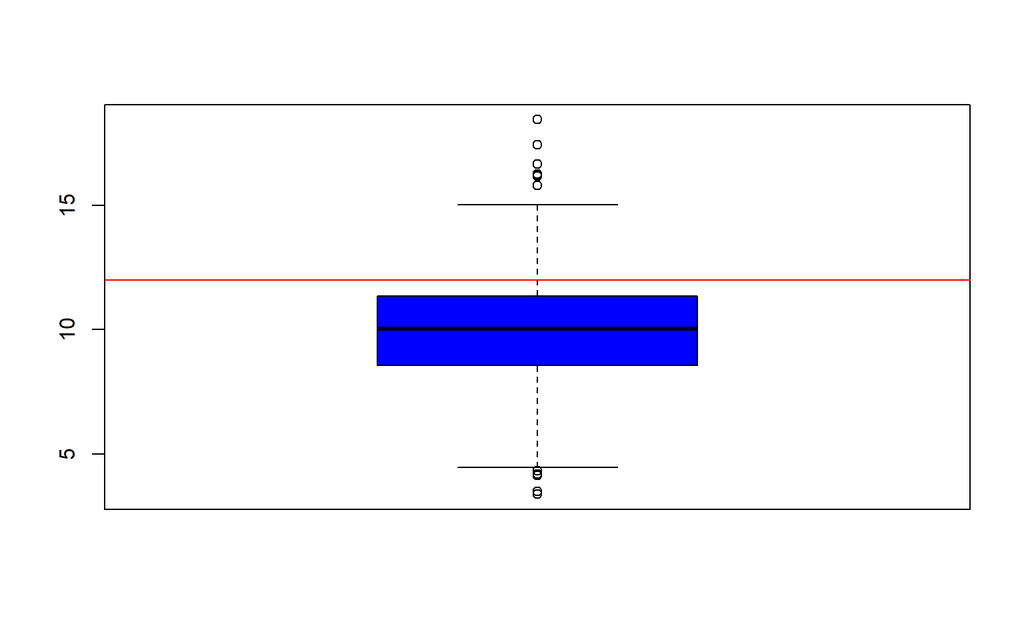

```r
boxplot(pollution$pm25, col="blue")
abline(h=12, col="red") # Linha horizontal no valor 12
```

- Para múltiplos boxplots, usamos `<variável_numérica> ~ <variável categórica>`:

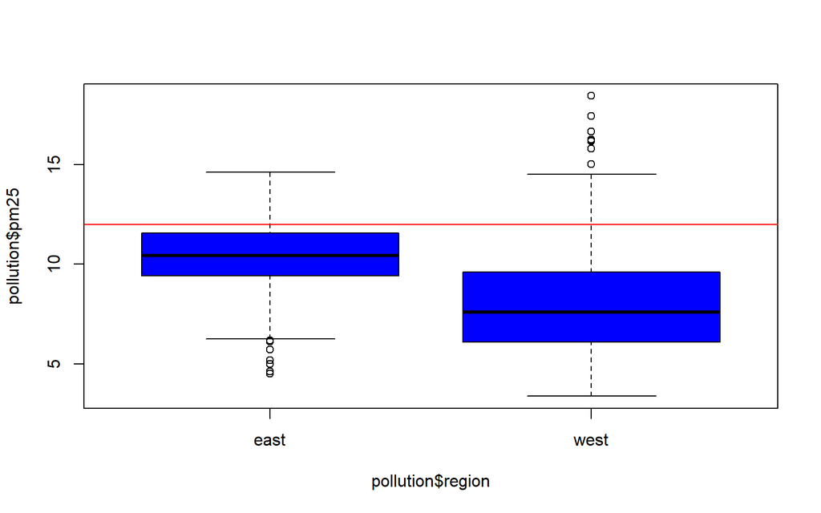

```r
boxplot(pollution$pm25 ~ pollution$region, col="blue")
abline(h=12, col="red") # Linha horizontal no valor 12
```

### Histograma

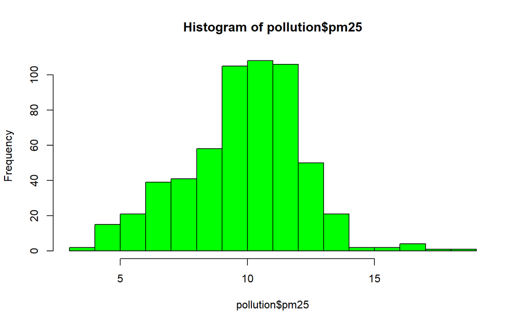

```r
hist(pollution$pm25, col="green")
```

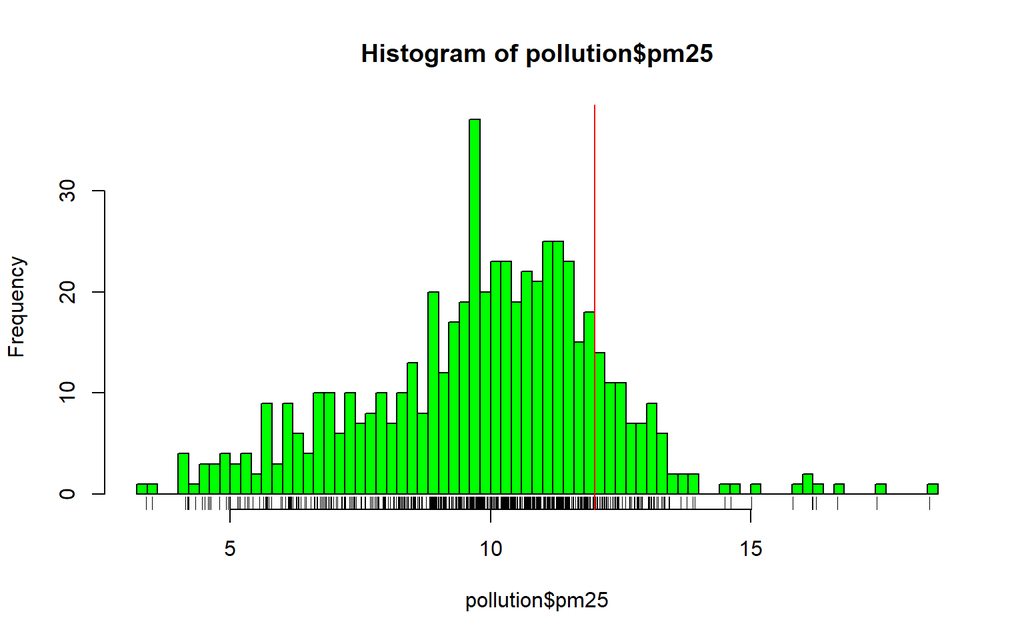

```r
hist(pollution$pm25, col="green", breaks=100) # 100 quebras
rug(pollution$pm25) # Traços dos valores da amostra abaixo do histograma
abline(v=12, col="red") # Linha vertical no valor 12
```

- Podemos colocar mais de um gráfico numa figura usando a função `par(mfrow, mar)`:

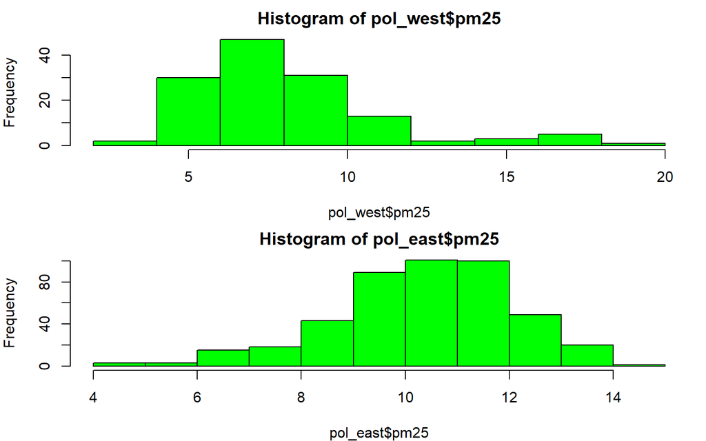

```r
par(mfrow=c(2, 1), mar=c(4, 4, 2, 1)) # Criando figura com 2 linhas e 1 coluna + margens

pol_west = pollution %>% filter(region == "west")
pol_east = pollution %>% filter(region == "east")

hist(pol_west$pm25, col="green")
hist(pol_east$pm25, col="green")
```

- Note que você precisa usar `par(mfrow=c(1, 1))` para voltar a incluir apenas 1 gráfico na figura.

### Gráfico de barra (*Barplot*)

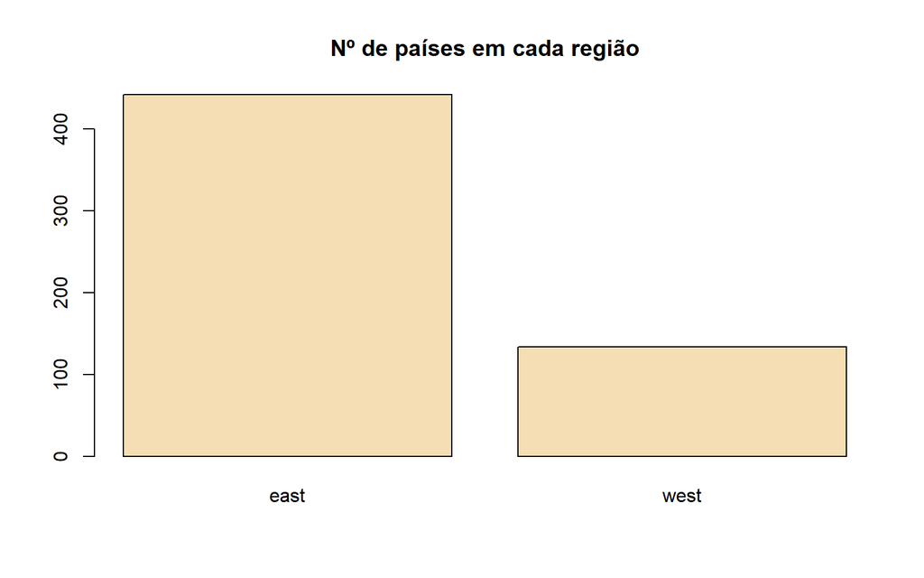

```r
barplot(table(pollution$region), col="wheat",
        main="Nº de países em cada região")
```

### Gráfico de dispersão (*Scatterplot*)

- Gera gráficos sob 2 dimensões

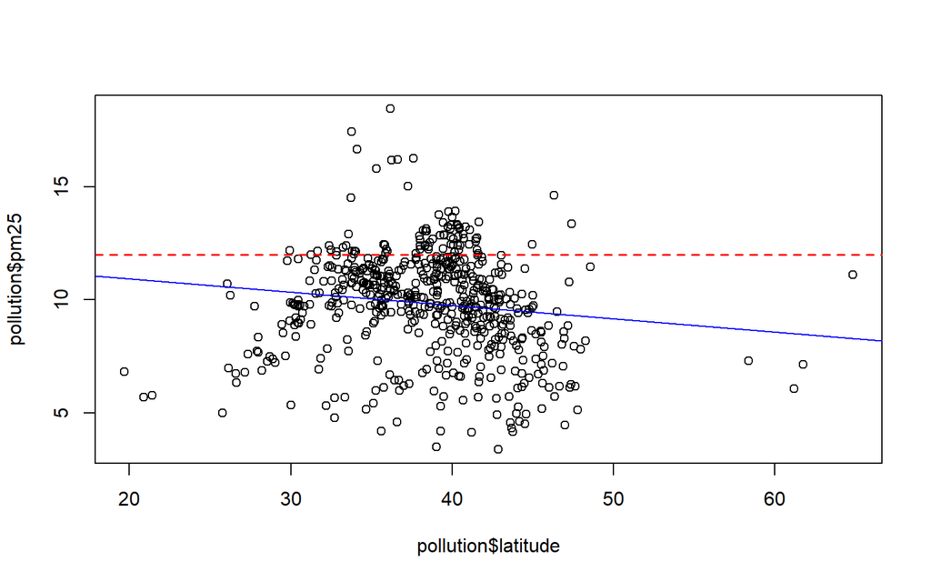

```r
plot(pollution$latitude, pollution$pm25)
abline(h=12, lwd=1.5, lty=2, col="red")
abline(lm(pm25 ~ latitude, data=pollution), col="blue")
```

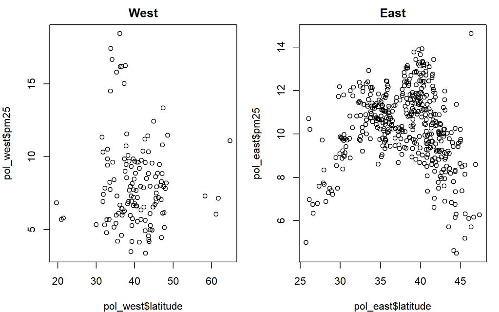

```r
par(mfrow=c(1, 2), mar=c(4, 4, 2, 1)) # Criando figura com 1 linha e 2 colunas + margens

plot(pol_west$latitude, pol_west$pm25, main="West")
plot(pol_east$latitude, pol_east$pm25, main="East")
```

- Também é possível adicionar objetos gráficos e textos no gráfico gerado por `plot()`:
  - `abline()`: adiciona linhas horizontal, vertical ou de regressão
  - `points()`: adiciona pontos ao gráfico
  - `lines()`: adiciona linhas ao gráfico
  - `text()`: adiciona texto ao gráfico
  - `title()`: adiciona anotações aos eixos, título, subtítulo e margem exterior
  - `mtext()`: adiciona texto às margens (interna e externa) do gráfico
  - `axis()`: adiciona traços/rótulos aos eixos

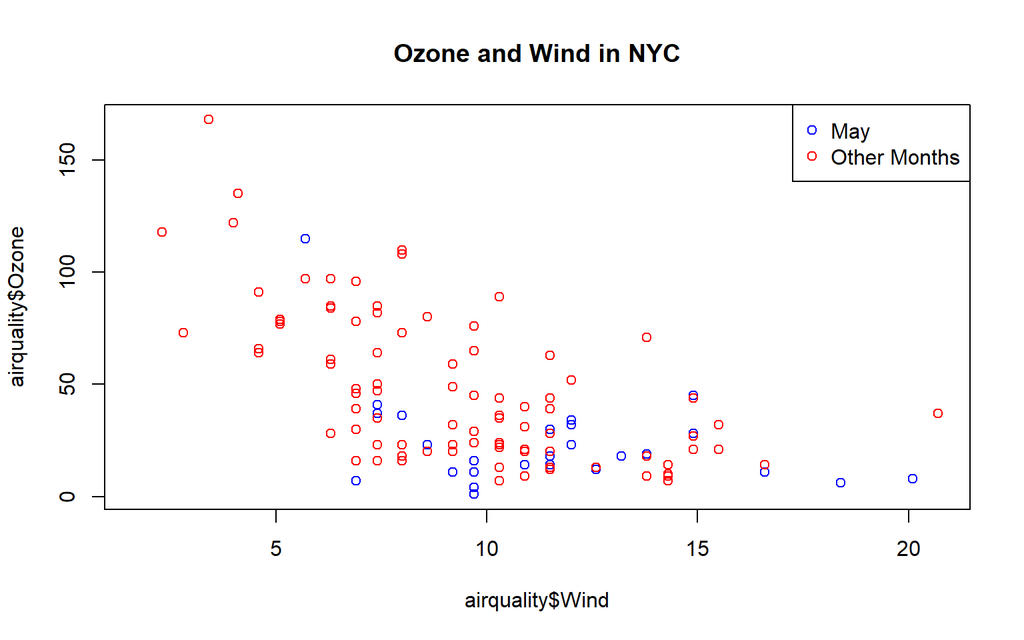

```r
par(mfrow=c(1, 1)) # Retornando ao padrão

air_may = airquality %>% filter(Month==5)
air_other = airquality %>% filter(Month!=5)

plot(airquality$Wind, airquality$Ozone, main="Ozone and Wind in NYC")
points(air_may$Wind, air_may$Ozone, col="blue")
points(air_other$Wind, air_other$Ozone, col="red")
legend("topright", pch=1, col=c("blue", "red"), legend=c("May", "Other Months"))
```

Alguns parâmetros gráficos importantes:

- `pch`: símbolo dos pontos gráficos (padrão é círculo)
- `lty`: tipo da linha (padrão é linha sólida, mais pode ser pontilhado, etc.)
- `lwd`: grossura da linha (integer)
- `col`: cor, especificada como número, texto ou código hex (função `colors()` dá um vetor de cores por nome)
- `xlab`: rótulo do eixo x
- `ylab`: rótulo do eixo y
- `par()`: função que especifica parâmetros *globais* que afetam todas figuras:
  - `las`: orientação dos rótulos
  - `bg`: cor de fundo
  - `mar`: tamanho da margem
  - `oma`: tamanho da margem externa (padrão é 0)
  - `mfrow`: número de gráficos por linha
  - `mfcol`: número de gráficos por coluna

## Grammar of Graphics (pacote `ggplot2`)

- [*ggplot2* - Part 3 (John Hopkins/Coursera)](https://www.coursera.org/learn/exploratory-data-analysis/lecture/idcsq/ggplot2-part-3)
- [*ggplot2* - Part 4 (John Hopkins/Coursera)](https://www.coursera.org/learn/exploratory-data-analysis/lecture/cj6RA/ggplot2-part-4)
- [*ggplot2* Cheat Sheet](https://raw.githubusercontent.com/rstudio/cheatsheets/main/data-visualization.pdf)
- [Aplicações *ggplot2* (The R Graph Gallery)](https://r-graph-gallery.com/ggplot2-package.html)
- Componentes básicos do `ggplot2`:
  - um **data frame**
  - estética (**aesthetics**): como os dados são mapeados (tamanho, forma, cor)
  - objetos geométricos (**geoms**): pontos, linhas, formas
  - **facets**: para gráficos condicionais
- Ao invés de criar um gráfico diretamente, os gráficos do `ggplot2` são construídos em camadas (layers)
1. Data Frame

```r
head(mtcars)
```

```
##                    mpg cyl disp  hp drat    wt  qsec vs am gear carb
## Mazda RX4         21.0   6  160 110 3.90 2.620 16.46  0  1    4    4
## Mazda RX4 Wag     21.0   6  160 110 3.90 2.875 17.02  0  1    4    4
## Datsun 710        22.8   4  108  93 3.85 2.320 18.61  1  1    4    1
## Hornet 4 Drive    21.4   6  258 110 3.08 3.215 19.44  1  0    3    1
## Hornet Sportabout 18.7   8  360 175 3.15 3.440 17.02  0  0    3    2
## Valiant           18.1   6  225 105 2.76 3.460 20.22  1  0    3    1
```

2. Base do Gráfico (`ggplot()`)
   - dados que serão incluídos no gráfico
   - toda vez que for incluir uma variável, é necessário precisa usar a função `aes()` sobre elas

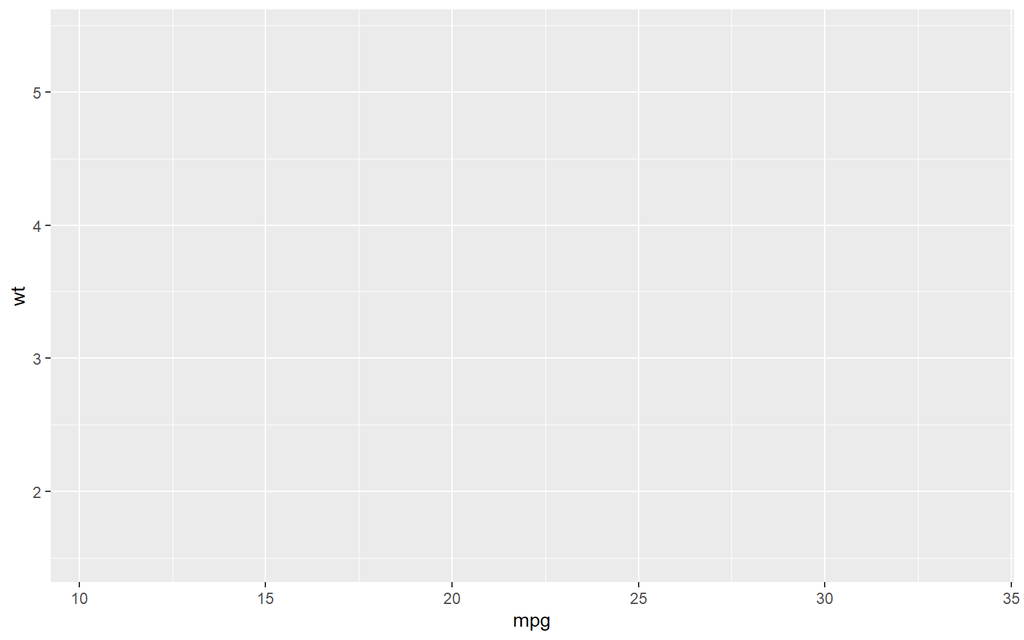

```r
library(ggplot2)
g = ggplot(data=mtcars, aes(mpg, wt)) # Criando a base do gráfico
g
```

3. Layer geomético (`geom`)
   - incluindos formas, linhas e pontos
   - caso não sejam informadas novas variáveis, a função para criar um objeto geométrico irá usar as variáveis-base definidas na função `ggplot()` inicial
   - Junta-se a base do gráfico com outras layers usando o sinal `+`

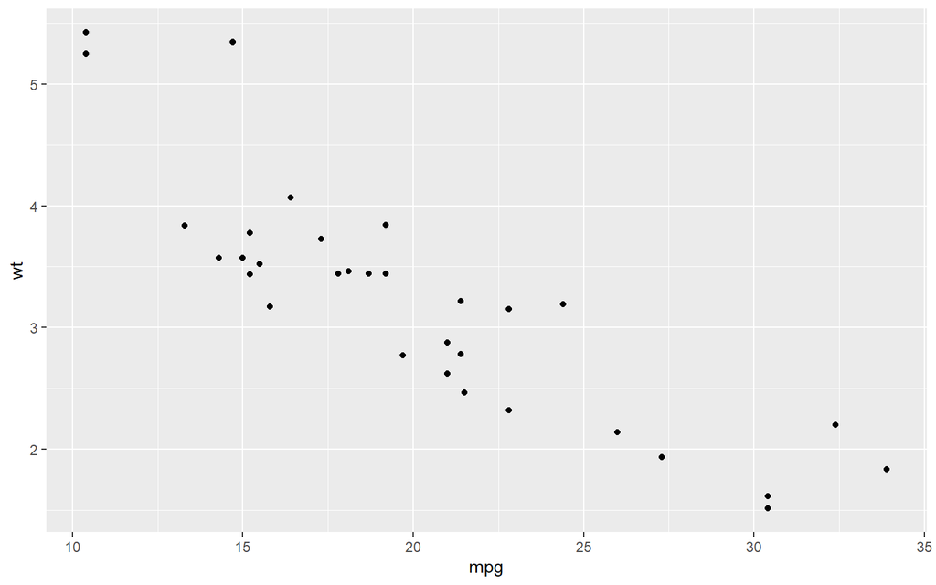

```r
g + geom_point()
```

4. Layer de suavização/tendência (`smooth`)

```yaml
geom_smooth(
  mapping = NULL, data = NULL, ...,
  method = NULL, formula = NULL, se = TRUE, level = 0.95
)

mapping: Set of aesthetic mappings created by aes() or aes_(). If specified and inherit.aes = TRUE (the default), it is combined with the default mapping at the top level of the plot. You must supply mapping if there is no plot mapping.
data: The data to be displayed in this layer. If NULL, the default, the data is inherited from the plot data as specified in the call to ggplot().
method: Smoothing method (function) to use, accepts either NULL or a character vector, e.g. "lm", "glm", "gam", "loess" or a function (...).
formula: Formula to use in smoothing function, eg. y ~ x, y ~ poly(x, 2), y ~ log(x).
se: Display confidence interval around smooth? (TRUE by default, see level to control.)
level: Level of confidence interval to use (0.95 by default).
```

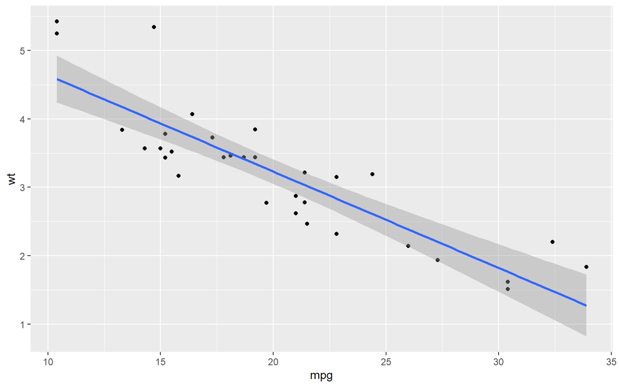

```r
g + geom_point() + geom_smooth(method="lm") # suavização a partir de MQO
```

5. Layers condicionais Facets (usar `cyl`)

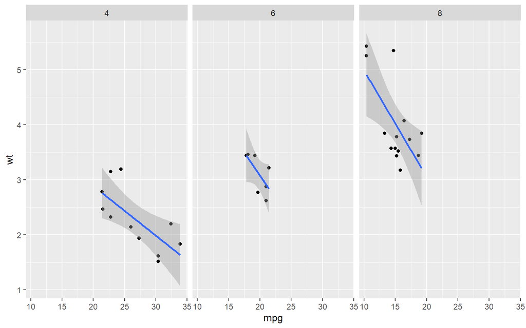

```r
g + geom_point() + geom_smooth(method="lm") + facet_grid(. ~ cyl) # agrupando por nº cilindros horizontalmente
```

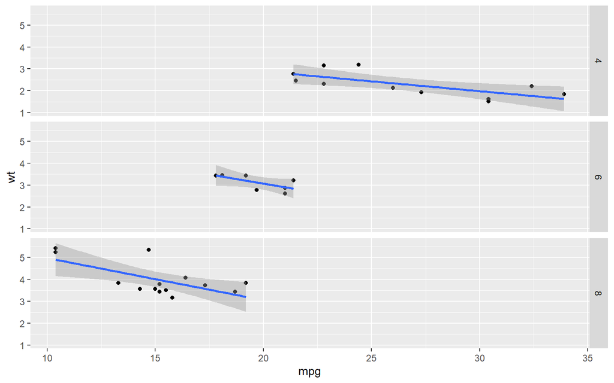

```r
g + geom_point() + geom_smooth(method="lm") + facet_grid(cyl ~ .) # agrupando por nº cilindros verticalmente
```

6. Anotações
   - Rótulos: `xlab()`, `ylab()`, `labs()`, `ggtitle()`
   - Cada *geom* tem opções para modificar, mas use `theme()` para opções globais do gráfico. Use `?theme` e veja a quantidade de configurações você pode fazer no seu gráfico.
   - Se quiser temas pré-definidos, há 2 templates padrão `theme_gray()` e `theme_bw()` (preto/branco). Também é possível usar outros usando o pacote `ggthemes`.

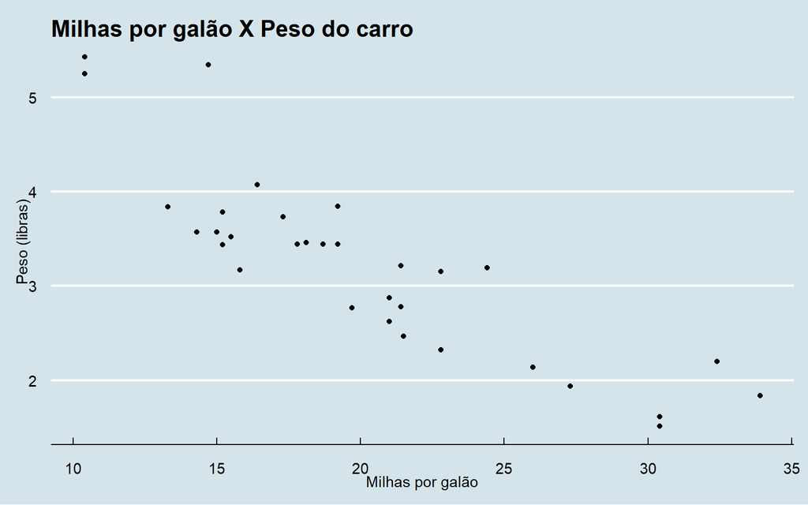

```r
g + geom_point() + ggthemes::theme_economist() +
    ylab("Peso (libras)") + xlab("Milhas por galão") +
    ggtitle("Milhas por galão X Peso do carro")
```

7. Modificando Estética
   - Dentro de cada *geom*, podemos definir a cor (`color`), o tamanho (`size`) e a transparência (`alpha`)

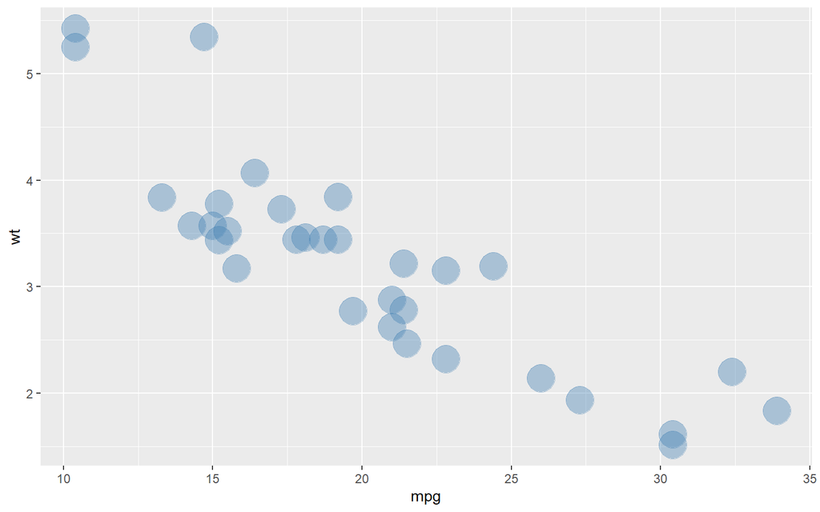

```r
g + geom_point(color="steelblue", size=9, alpha=0.4)
```

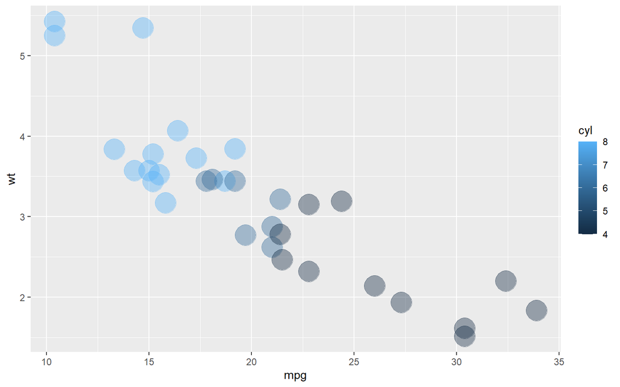

```r
g + geom_point(aes(color=cyl), size=9, alpha=0.4) # colorindo por variável - precisa usar aes()
```

# ECONOMETRIA ============

- A parte de Econometria no R é baseada no livro de Florian Heiss “Using R for Introductory Econometrics” (2ª edição, 2020)
  - Aplicar no R o conteúdo e os exemplos do livro do Wooldridge de 2019 (versão em inglês)
  - É possível ler gratuitamente a versão online em: http://www.urfie.net
  - Há também uma versão de Python do livro em: http://www.upfie.net
- A base de dados dos exemplos contidos no livro do Wooldridge podem ser obtidos por meio da instalação e do carregamento do pacote `wooldridge`:

```r
# install.packages("wooldridge")
library(wooldridge)
```

# Distribuições

- [Seção 1.7 de Heiss (2020)](http://www.urfie.net/read/index.html#page/65)
- [Probability Distributions in R (Examples): PDF, CDF & Quantile Function (Statistics Globe)](https://statisticsglobe.com/probability-distributions-in-r)
- [Basic Probability Distributions in R (Greg Graham)](https://rstudio-pubs-static.s3.amazonaws.com/100906_8e3a32dd11c14b839468db756cee7400.html)
- As funções relacionadas a distribuições são dadas por `<prefixo><nome da distribuição>`
- Existem 4 prefixos que indicam qual ação será realizada:
  - `d`: retorna uma probabilidade a partir de uma função de densidade de probabilidade (fdp)
  - `p`: retorna uma probabilidade acumulada a partir de uma função de distribuição acumulada (fda)
  - `q`: retorna uma estatística da distribuição (quantil) dada uma probabilidade acumulada
  - `r`: gera números aleatórios dada a distribuição
- Existem diversas distribuições disponíveis no R:
  - `norm`: Normal
  - `bern`: Bernoulli (pacote `Rlab`)
  - `binom`: Binomial
  - `pois`: Poisson
  - `chisq`: Qui-Quadrado ($\chi^2$)
  - `t`: t-Student
  - `f`: F
  - `unif`: Uniforme
  - `weibull`: Weibull
  - `gamma`: Gamma
  - `logis`: Logística
  - `exp`: Exponencial
- Seguem as principais distribuições e suas respectivas funções:

| **Distribuição** | **Densidade de Probabilidade** | **Distribuição Acumulada** | **Quantil** |
| --- | --- | --- | --- |
| Normal | `dnorm(x, mean, sd)` | `pnorm(q, mean, sd)` | `qnorm(p, mean, sd)` |
| Qui-Quadrado | `dchisq(x, df)` | `pchisq(q, df)` | `qchisq(p, df)` |
| t-Student | `dt(x, df)` | `pt(q, df)` | `qt(p, df)` |
| F | `df(x, df1, df2)` | `pf(q, df1, df2)` | `qf(p, df1, df2)` |
| Binomial | `dbinom(x, size, prob)` | `pbinom(q, size, prob)` | `qbinom(p, size, prob)` |

em que `x` e `q` são estatísticas de cada distribuição (quantis), e `p` é probabilidade.

## Distribuição Normal

[figure not shown]

- [`d`]: Densidade a partir de uma fdp, dada estatística (escore padrão):

```r
dnorm(1.96, mean=0, sd=1) # probabilidade para escore padrão de 1,96
```

```
## [1] 0.05844094
```

```r
dnorm(-1.96, mean=0, sd=1) # probabilidade para escore padrão de -1,96
```

```
## [1] 0.05844094
```

- [`p`]: Probabilidade acumulada a partir de uma fda, dada estatística (escore padrão):

```r
pnorm(1.96, mean=0, sd=1) # probabilidade acumulada para escore padrão de 1,96
```

```
## [1] 0.9750021
```

```r
pnorm(-1.96, mean=0, sd=1) # probabilidade acumulada para escore padrão de -1,96
```

```
## [1] 0.0249979
```

Logo, a probabilidade de que uma variável aleatória com distribuição normal padrão esteja com valor entre -1,96 e 1,96 é de 95%

```r
pnorm(1.96, mean=0, sd=1) - pnorm(-1.96, mean=0, sd=1)
```

```
## [1] 0.9500042
```

- [`q`]: Estatística (escore padrão) a partir de um quantil:

```r
qnorm(0.975, mean=0, sd=1) # quantil dada o quantil de 97,5%
```

```
## [1] 1.959964
```

```r
qnorm(0.025, mean=0, sd=1) # quantil dada o quantil de 2,5%
```

```
## [1] -1.959964
```

Podemos criar gráficos usando a função `curve( function(x), from, to )`, na qual inserimos uma função com um `x` arbitrário e seus limites mínimo e máximo (`from` e `to`):

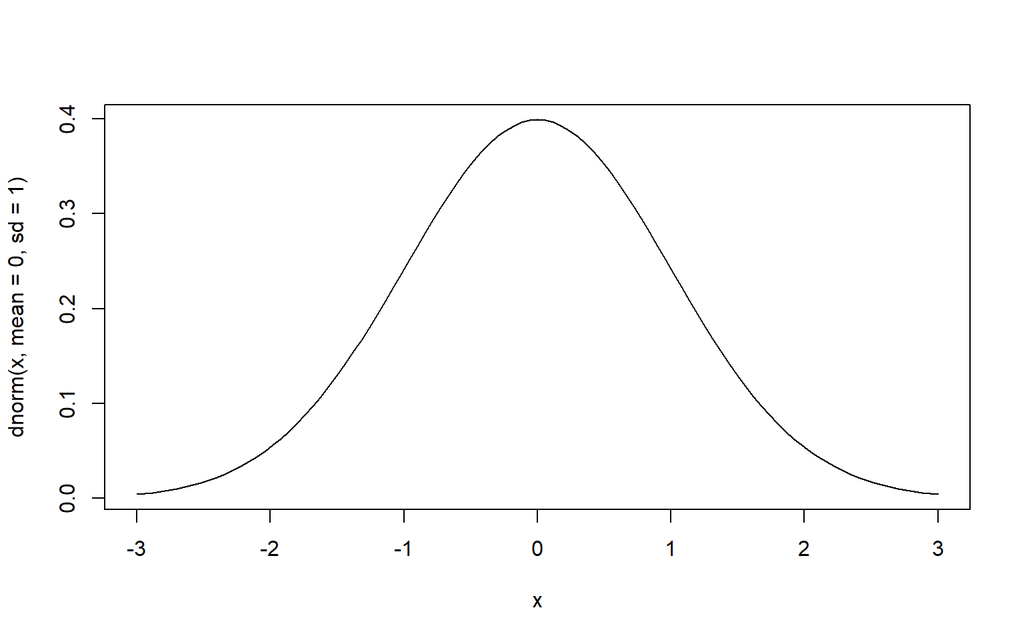

```r
# pdf de normal padrão com estatística (escore padrão) no intervalo -3 e 3
curve(dnorm(x, mean=0, sd=1), from=-3, to=3)
```

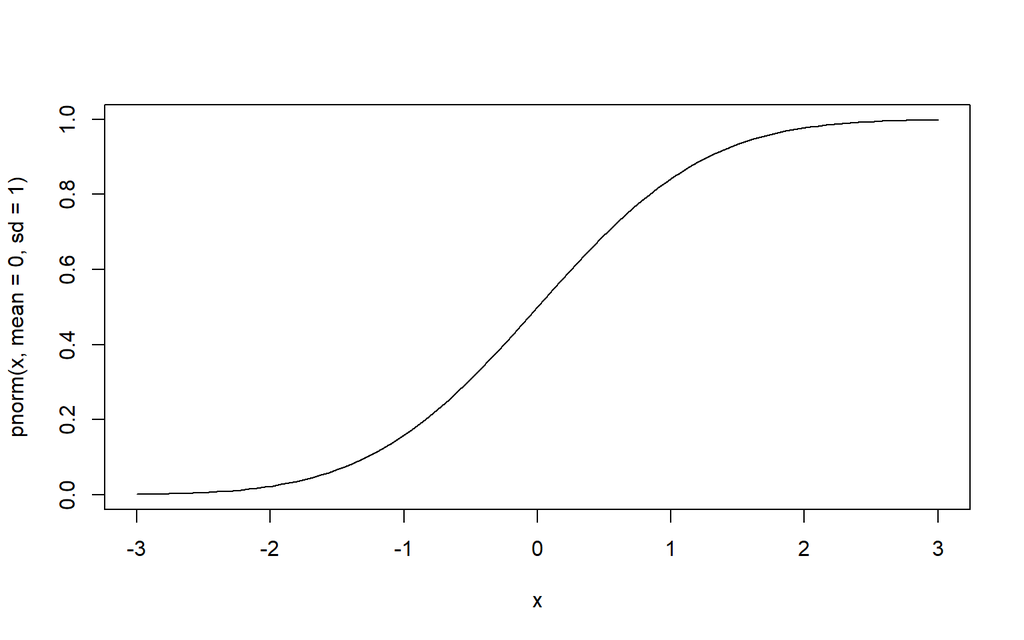

```r
# cdf de normal padrão com estatística (escore padrão) no intervalo -3 e 3
curve(pnorm(x, mean=0, sd=1), from=-3, to=3)
```

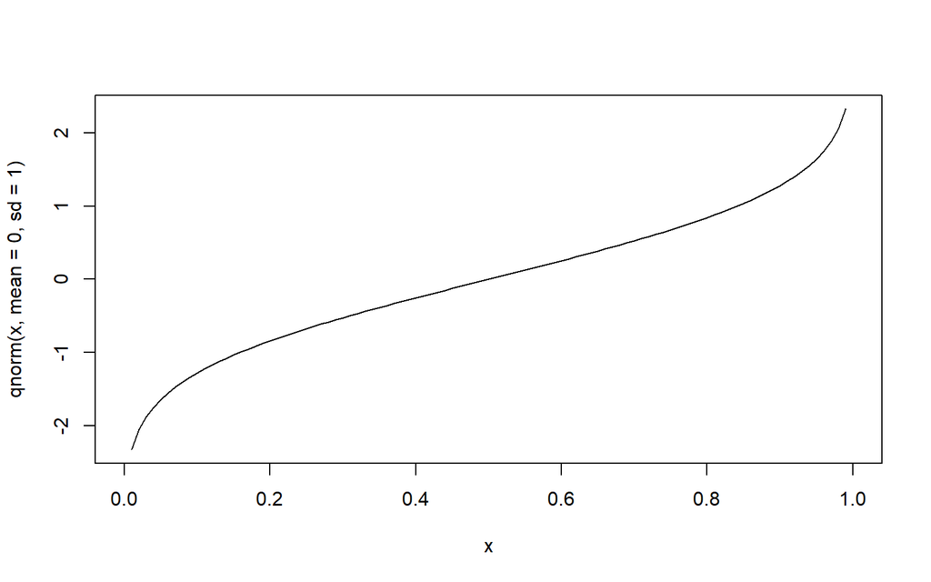

```r
# quantil de normal padrão com probabilidade acumulada no intervalo 0 e 1
curve(qnorm(x, mean=0, sd=1), from=0, to=1)
```

## Distribuição t-Student

- Criaremos gráficos com diversos graus de liberdade
- Quanto maior os graus de liberdade, mais se aproxima de uma normal padrão

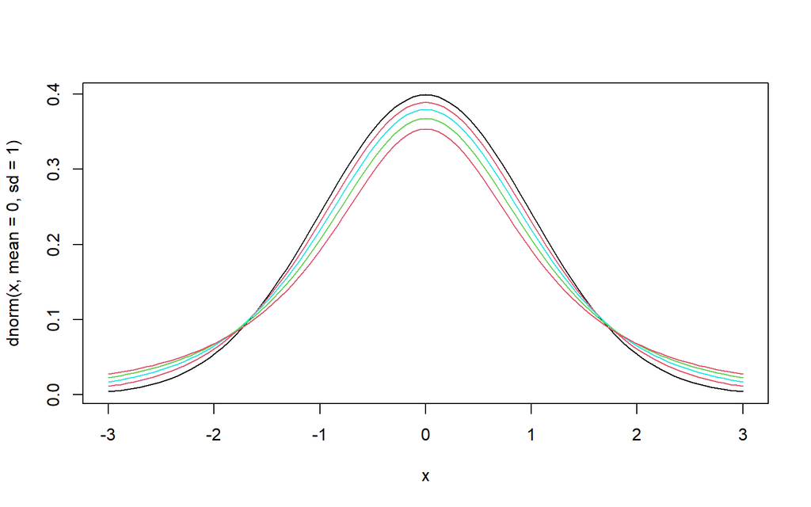

```r
curve(dnorm(x, mean=0, sd=1), from=-3, to=3, pch=".") # fdp normal padrão

for (n in c(10, 5, 3, 2)) {
    curve(dt(x, df=n), from=-3, to=3, col=n, add=T) # fdp t-student
}
```

# Simulação

## Amostragem aleatória

- [Simulation - Random sampling (John Hopkins/Coursera)](https://www.coursera.org/learn/r-programming/lecture/ykXUb/simulation-random-sampling)
- Para fazer uma amostragem a partir de um dado vetor, usamos a função `sample()`

```yaml
sample(x, size, replace = FALSE, prob = NULL)

x: either a vector of one or more elements from which to choose, or a positive integer. See ‘Details.’
n: a positive number, the number of items to choose from.
size: a non-negative integer giving the number of items to choose.
replace: should sampling be with replacement?
prob: a vector of probability weights for obtaining the elements of the vector being sampled.
```

```r
sample(letters, 5) # Amostragem de 5 letras
```

```
## [1] "l" "e" "p" "j" "s"
```

```r
sample(1:10, 4) # Amostragem de 4 números de 1 a 10
```

```
## [1] 2 8 9 1
```

```r
sample(1:10) # Permutação (amostra mesma qtd de elementos do vetor)
```

```
##  [1]  2  5  9  6  7  1 10  3  8  4
```

```r
sample(1:10, replace = TRUE) # Amostragem com reposição
```

```
##  [1]  8 10  1  7  9  9  3  3  4  3
```

- Note que, por padrão, a função `sample()` faz a amostragem sem reposição.

### Visualizando a Lei dos Grandes Números (LGN)

- Podemos usar a amostragem para simular jogadas de dado não viesado.
- Vamos jogar uma vez o dado:

```r
sample(1:6, 1) # amostra um número dentro do vetor 1:6
```

```
## [1] 6
```

- Vamos jogar 500 vezes o dado (usando função `replicate()`) e verificar sua distribuição:

```r
amostra = replicate(500, expr=sample(1:6, 1))
table(amostra) # tabela com contagem das jogadas
```

```
## amostra
##  1  2  3  4  5  6
## 89 93 91 65 82 80
```

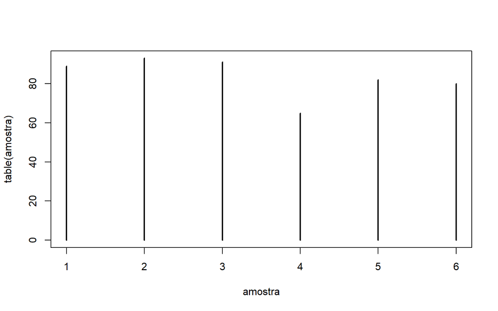

```r
# Gráfico
plot(table(amostra), type="h")
```

- Note que não podemos usar a função `rep()` com simulação, pois ele sortearia um número e replicaria esse mesmo número 500 vezes. - Agora, vamos jogar 2 vezes o dado e fazer a média entre eles

```r
mean(sample(1:6, 2))
```

```
## [1] 3.5
```

- Fazendo isso 500 vezes, temos:

```r
amostra = replicate(500, mean(sample(1:6, 2, replace=T)))
table(amostra) # tabela com contagem das médias de 2 jogadas
```

```
## amostra
##   1 1.5   2 2.5   3 3.5   4 4.5   5 5.5   6
##  15  16  39  48  70  79  95  57  47  25   9
```

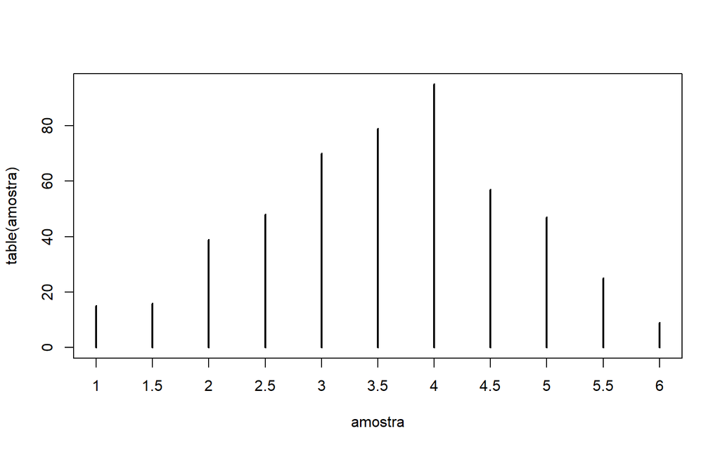

```r
# Gráfico
plot(table(amostra), type="h")
```

- Note que, ao repetir 500 vezes, o cálcilo da média de 2 jogadas de dado, começou a dar mais peso para médias próximas à média populacional (3,5), mas ainda tem densidade nos valores mais extremos (1 e 6)
- Foi necessário usar o argumento `replace=TRUE` para ter “reposição” dos números do dado
- Calculando 500 vezes a média de $N=100$ jogadas de dado, temos:

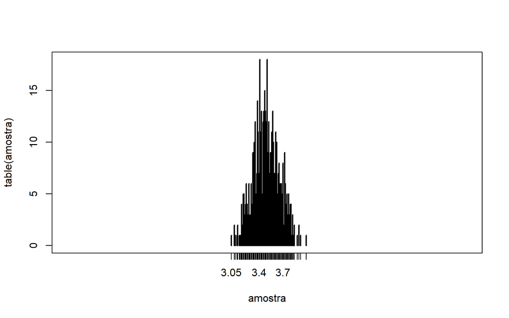

```r
N = 100
amostra = replicate(500, mean(sample(1:6, N, replace=T)))

# Gráfico
plot(table(amostra), type="h", xlim=c(1,6))
```

- Note que, quanto maior $N$, a concentração das médias das amostragens se concentraram ainda mais próximo da média populacional (3,5). Além disso, a densidade de médias mais distantes ficaram praticamente nulas.

## Geração de números aleatórios

- Para gerar números aleatórios, usaremos o prefixo `r` junto de uma distribuição.

```r
rnorm(5) # gerando 5 números aleatórios
```

```
## [1]  1.1069861 -0.1852287  1.3556348  0.8025769 -0.3390595
```

- Para reproduzir resultados que usem números aleatórios, podemos definir “sementes” usando a função `set.seed()` e informando um número inteiro. Isso também é válido para a função `sample()`.

```r
# definindo seed
set.seed(2022)
rnorm(5)
```

```
## [1]  0.9001420 -1.1733458 -0.8974854 -1.4445014 -0.3310136
```

```r
# sem definir seed
rnorm(5)
```

```
## [1] -2.9006290 -1.0592557  0.2779547  0.7494859  0.2415825
```

```r
# definindo seed
set.seed(2022)
rnorm(5)
```

```
## [1]  0.9001420 -1.1733458 -0.8974854 -1.4445014 -0.3310136
```

# Intervalos de Confiança

- [Subseção 1.8.1 de Heiss (2020)](http://www.urfie.net/read/index.html#page/71)
- No Apêndice C.5 de Wooldridge (2006, em português), são construídos intervalos de confiança de 95%.
- Para uma população normalmente distribuída com média $\mu$ e variância $\sigma^2$, o intervalo de confiança com significância de $\alpha$ é dado por:
  $$\text{IC}_\alpha = \left[\bar{y} -
  C_{\alpha/2}.se(\bar{y}),\quad \bar{y} + C_{\alpha/2}.se(\bar{y})\right]
  \tag{1.2}$$
  em que:
- $\bar{y}$: média amostral
- $se(\bar{y}) = \frac{s}{\sqrt{n}}$: erro padrão de $\bar{y}$
- $s$: desvio padrão de $\bar{y}$
- $n$: tamanho da amostra
- $C_{\alpha/2}$: é o valor crítico do quantil de $(1-\alpha/2)$ da distribuição $t_{n-1}$.
  - Por exemplo, para $\alpha = 5\%$, usa-se o quantil 97,5% ($= 1 - 5\%/2$).
  - Quando o número de graus de liberdade é grande, a distribuição *t* se aproxima ao de uma normal padrão. Logo, para um intervalo de confiança de 95%, o valor crítico é $C_{2,5\%} \approx 1,96$

### Exemplo C.2: Efeito de subsídios de treinamento corporativo sobre a produtividade do trabalhador (Wooldridge, 2006)

- Holzer, Block, Cheatham e Knott (1993) estudaram os efeitos de subsídios de treinamentos corporativos sobre a produtividade dos trabalhadores
- Para isto, avaliou-se a “taxa de refugo”, isto é, a quantidade de itens descartados a cada 100 itens produzidos.
- Entre 1987 e 1988, houve treinamento corporativo em 20 empresas e queremos saber se ele teve efeito sobre a taxa de refugo, ou seja, a diferença entre as médias dos anos foi estatisticamente significante (diferente de 0).
- Comecemos criando vetores de taxa de refugos das 20 empresas para os anos de 1987 (*SR87*) e de 1988 (*SR88*):

```r
SR87 = c(10, 1, 6, .45, 1.25, 1.3, 1.06, 3, 8.18, 1.67, .98,
         1, .45, 5.03, 8, 9, 18, .28, 7, 3.97)
SR88 = c(3, 1, 5, .5, 1.54, 1.5, .8, 2, .67, 1.17, .51, .5,
         .61, 6.7, 4, 7, 19, .2, 5, 3.83)
```

- Criando o vetor das variações das taxas de refugo e extraindo estatísticas:

```r
Change = SR88 - SR87 # vetor de variações
n = length(Change) # quantidade de empresas/tamanho do vetor Variacao
avgChange = mean(Change) # média do vetor Variacao
sdChange = sd(Change) # desvio padrão do vetor Variacao
```

- Calculando o erro padrão e o valor crítico para intervalo de confiança de 95%:

```r
se = sdChange / sqrt(n) # erro padrão
CV = qt(.975, n-1) # valor crítico para intervalo de confiança de 95%
```

- Finalmente, calcula-se o intervalo de confiança usando (1.2)

```r
c(avgChange - CV*se, avgChange + CV*se) # limites inferior e superior do intervalo
```

```
## [1] -2.27803369 -0.03096631
```

```r
# também poderíamos escrever o intervalo mais sucintamente:
avgChange + CV * c(-se, se)
```

```
## [1] -2.27803369 -0.03096631
```

- Note que o valor 0 está fora do intervalo de confiança de 95% e, portanto, conclui-se que houve alteração na taxa de refugo (houve efeito negativo estatisticamente significante).

# Teste *t* e p-valores

- [Subseções 1.8.2 e 1.8.3 de Heiss (2020)](http://www.urfie.net/read/index.html#page/74)
- Apêndice C.6 de Wooldridge (2006, em português)
- A estatística *t* para testar uma hipótese sobre uma variável aleatória $y$ normalmente distribuída com média $\bar{y}$ é dado pela equação C.35 (Wooldridge, 2006). Dada a hipótese nula $H_0: \bar{y} = \mu_0$,
  $$t = \frac{\bar{y} - \mu_0}{se(\bar{y})}.
  \tag{1.3}$$
- Para rejeitarmos a hipótese nula, o módulo da estatística *t* precisa ser maior do que o valor crítico, dado um nível de significância $\alpha$.
- Por exemplo, ao nível de significância $\alpha = 5\%$ e com uma grande amostra (e, portanto, a distribuição *t* se aproxima a de uma normal padrão), rejeitamos a hipótese nula se
  $$|t| \ge 1,96
  \approx \text{valor crítico ao nível de significância de 5%}$$
- A vantagem de utilizar o p-valor é a sua conveniência, pois pode-se compará-lo diretamente com o nível de significância.
- Para testes *t* bicaudais, a fórmula do p-valor é dado por (Wooldridge, 2006, equação C.42):
  $$p =
  2.Pr(T_{n-1} > |t|) = 2.[1 - F_{t_{n-1}}(|t|)]$$
  em que $F_{t_{n-1}}(\cdot)$ é a fda da distribuição $t_{n-1}$.

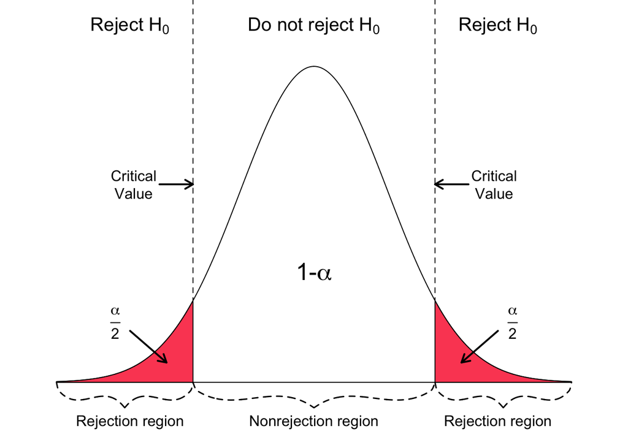

- Rejeitamos a hipótese nula se o p-valor for menor do que o nível de significância $\alpha$.

### Exemplo C.6: Efeito de subsídios de treinamento corporativo sobre a produtividade do trabalhador (Wooldridge, 2006)

- Continuação do exemplo C.2
- Considerando teste bicaudal (diferente dos livros), podemos calcular a estatística *t*

```r
# Estatística t para H0: mu = 0
t = (avgChange - 0) / se
print(paste0("estatística t = ", abs(t), " > ", CV, " = valor crítico"))
```

```
## [1] "estatística t = 2.15071100397349 > 2.09302405440831 = valor crítico"
```

- Como estatística *t* é maior do que o valor crítico, rejeitamos $H_0$ a nível de significância de 5%.
- De forma equivalente, podemos calcular o p-valor:

```r
p = 2 * (1 - pt(abs(t), n-1))
print(paste0("p-valor = ", p, " < 0.05 = nível de significância"))
```

```
## [1] "p-valor = 0.0445812529367844 < 0.05 = nível de significância"
```

## Cálculos automáticos via `t.test()`

```yaml
t.test(x, y = NULL,
       alternative = c("two.sided", "less", "greater"),
       mu = 0, paired = FALSE, var.equal = FALSE,
       conf.level = 0.95, ...)

x: (non-empty) numeric vector of data values.
alternative: a character string specifying the alternative hypothesis, must be one of "two.sided" (default), "greater" or "less". You can specify just the initial letter.
mu: a number indicating the true value of the mean (or difference in means if you are performing a two sample test).
conf.level: confidence level of the interval.
```

- Note que incluiremos um vetor de valor no argmento `x` e, por padrão, a função considera um teste bicaudal, testando a $H_0$ se média verdadeira é igual a zero e com intervalo de confiança de 95%.
- Retornando aos exemplos C.2 e C.6 (“Efeito de subsídios de treinamento corporativo sobre a produtividade”), temos:

```r
testresults = t.test(Change)
testresults
```

```
##
##  One Sample t-test
##
## data:  Change
## t = -2.1507, df = 19, p-value = 0.04458
## alternative hypothesis: true mean is not equal to 0
## 95 percent confidence interval:
##  -2.27803369 -0.03096631
## sample estimates:
## mean of x
##   -1.1545
```

- Dentro do objeto de resultado do teste, temos as seguintes informações:

```r
names(testresults)
```

```
##  [1] "statistic"   "parameter"   "p.value"     "conf.int"    "estimate"
##  [6] "null.value"  "stderr"      "alternative" "method"      "data.name"
```

- Podemos, por exemplo, acessar o p-valor usando:

```r
testresults$p.value
```

```
## [1] 0.04458125
```